# CP-2007: Análisis Político Cuantitativo 2

Profesor: Steffan Gómez Campos

Email: steffangc@gmail.com

Escuela de Ciencias Políticas

Universidad de Costa Rica

Segundo semestre de 2025

# Introducción

Este documento recopila los principales conceptos y la programación en R del curso CP-2007, Análisis Político Cuantitativo 2. Es una guía para el estudiante con el objetivo de facilitar el análisis estadístico descriptivo e inferencial y la interpretación de los resultados. Esta es la segunda versión. Hay otro documento similar a este del curso CP-2004, Análisis Político Cuantitativo 1, que introduce a los estudiantes en el software para análisis estadístico R, y en los conceptos básicos de estadística descriptiva y análisis político.

Esta guía incluye breves descripciones conceptuales de los principales temas del curso, e implementa ejemplos con código en R. El desarrollo de temas y conceptos son extractos de las referencias bibliográficas del curso. Se pueden ver con detalle al final de este documento. Son particularmente importantes los siguientes:

- Levin, J. (1999). Fundamentos de estadística en la investigación social. Oxford: Oxford University Press. Lewis-Beck.
- Gujarati, D. N., y Porter, D. C. (2011). Econometría Básica. México: McGraw Hill.
- Gómez, M. (2016). Elementos de estadística descriptiva. San José: Universidad Estatal a Distancia.
- Cardona, D. et.al. 2013. Inferencia estadística módulo de regresión lineal simple /Bogotá: Editorial Universidad del Rosario, Escuela de Administración.
- Camarero, L. et.al. sf. Regresión Logística: Fundamentos y aplicación a la investigación sociológica. Departamento de Sociología I, UNED. España.

La programación en este documento fue realizada en sistema operativo Mac OS (Apple). Existen pequeñas variaciones en el código con respecto al sistema Windows, en específico, en la definición del directorio de trabajo.

Como parte del curso es central desarrollar el componente de análisis e interpretación de datos. Esto consiste en dos elementos:

- La explicación estadística correcta de los indicadores y mediciones estudiadas.
- Que esté redactada de forma sencilla y directa para entendimiento, incluso, de audiencias no expertas en métodos estadísticos.

Para comprobar si las respuestas de los análisis son sencillas de entender, se puede utilizar esta herramienta en línea que permite incluir el texto del análisis y evalúa si está redactado en un español sencillo y claro: https://legible.es

# La curva normal

Antes de iniciar con el código, vale la pena un breve repaso de las características en la curva normal. Como se indica en el texto de Levin (1999), la curva normal es un tipo de curva uniforme y simétrica cuya forma recuerda a muchos una campana y por tanto se conoce como la ‘curva en forma de campana’. Tal vez el rasgo más sobresaliente de la curva normal es su simetría: si doblamos la curva en su punto más alto al centro, crearíamos, dos mitades iguales, cada una fiel imagen de la otra. Además, la curva normal es unimodal, ya que sólo tiene un pico o punto de máxima frecuencia —aquel punto en la mitad de la curva en el cual coinciden la media, la mediana y la moda— (el alumno recordará que la media, la mediana y la moda ocurren en distintos puntos en una distribución sesgada, ver Capítulo 3). Desde el pico central redondeado de la distribución normal, la curva cae gradualmente en ambas colas, extendiéndose indefinidamente en una y otra dirección y acercándose más y más a la línea de base sin alcanzarla realmente.

Para poder emplear la curva normal en la resolución de problemas, debemos familiarizarnos con el área bajo la curva normal: aquella área que está entre la curva y la línea base y que contiene el 100 por ciento, o todos los casos, en una distribución normal dada (Figura 1).

**Figura 1**

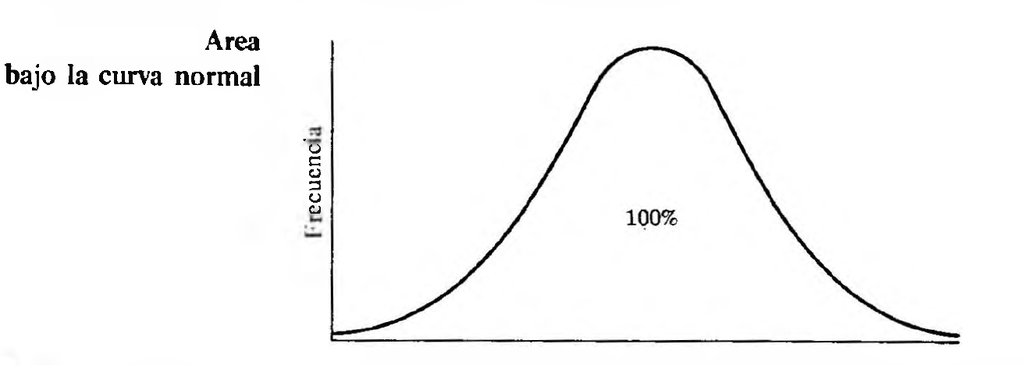

Fuente: Levin, 1999

La naturaleza simétrica de la curva normal nos lleva a otra importante conclusión; a saber, que cualquier distancia sigma ($\sigma$ - desviación estándar) dada arriba de la media $\bar{X}$, contiene una proporción idéntica de casos que la misma distancia sigma por abajo de la media. Así, si el 34,13% del área está entre la media y 1 desviación estándar (DE) por arriba de $\bar{X}$, entonces el 34,13% del área total está entre la media y 1 DE por abajo de $\bar{X}$; si el 47,72% está entre la media y 2 DE por arriba de la $\bar{X}$, entonces el 47,72% está entre la media y 2 DE por abajo de $\bar{X}$; si el 49,87% está entre la media y 3 DE por arriba de $\bar{X}$, entonces el 49,87% está también entre la media y 3 DE por abajo de $\bar{X}$.  
En otras palabras, como se ilustra en la Figura 2, el 68,26% del área total de la curva normal (34,13% + 34.13%) caen entre —1$\sigma$ y + 1$\sigma$ de la media; el 95,44% del área (47,72% + 47,72%) caen entre -2$\sigma$ y +2$\sigma$ de la media; el 99.74%, o casi todos los casos (49,87% + 49,87%) caen entre —3$\sigma$ y + 3$\sigma$ de la media. Puede decirse, entonces que 6 DE, incluyen prácticamente todos los casos (más del 99%) bajo cualquier distribución normal.

**Figura 2**

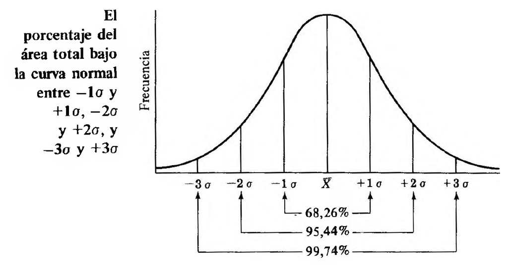

Fuente: Levin, 1999.

**Tabla 1. Valores Z**

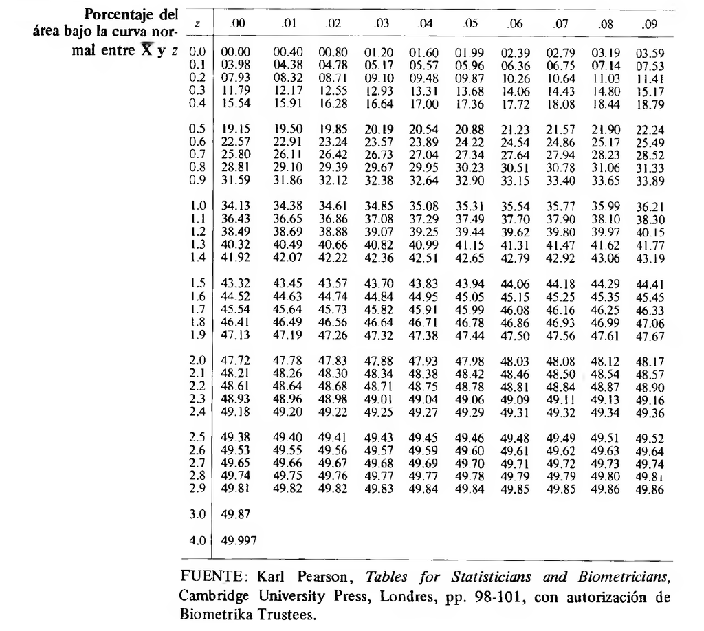

Fuente: Levin, 1999.

Para usar la Tabla Z, es necesario un procedimiento sencillo en dos pasos:

1. Convertir un valor específico de interés (también llamado puntaje crudo) en distancia sigma (distancias en función de la desviación estándar)
2. Encontrar esa distancia sigma en la Tabla de valores Z, para determinar el porcentaje del área total bajo la curva que representa el valor específico de interés.

El proceso que acabamos de ilustrar —de encontrar la distancia sigma de un valor específico— da un valor que se llama *puntaje z o estándar*, que indica la dirección y el grado en que cualquier puntaje crudo se desvía de la media de una distribución en una escala de unidades DE.

La distancia sigma de cualquier puntaje crudo se obtiene con la siguiente fórmula:

$$\begin{equation*}
z=\frac{X-\bar{X}}{\sigma}
\end{equation*}$$

donde:

X = valor específico de interés

$\bar{X}$ = media (promedio)

$\sigma$ = desviación estándar

Considerando que $X-\bar{X}$ denota el puntaje de desviación $(x)$, la fórmula se puede simplificar como:

$$\begin{equation*}
z=\frac{x}{\sigma}
\end{equation*}$$

Ejemplo 1:  
Considérese la distribución del ingreso anual en una ciudad en la cual el ingreso medio anual es de 5.000 dólares y la desviación estándar es 1.500. Suponiendo que la distribución del ingreso anual está normalmente distribuida, podemos convertir el puntaje crudo de esta distribución, 7.000, en un puntaje estándar, de la siguiente manera:

$$\begin{equation*}
z=\frac{7000-5000}{1500}=1,33
\end{equation*}$$

Entonces, un ingreso anual de 7.000 dólares está a 1,33 desviaciones estándar por arriba del ingreso medio anual de 5.000 dólares.

Usando la Tabla de valores Z, podemos obtener la probabilidad de ocurrencia de un ingreso entre 5.000 y 7.000 dólares en la ciudad de este ejemplo. De acuerdo con los valores z, un 40,82% de la población tendrían un ingreso entre 5.000 y 7.000 dólares. Expresado como una probabilidad se puede decir que en esta ciudad existe una probabilidad, P = 0,41 (redondeado) de obtener un salario entre 5.000 y 7.000 dólares. La figura 3 muestra el área bajo la curva.

**Figura 3**

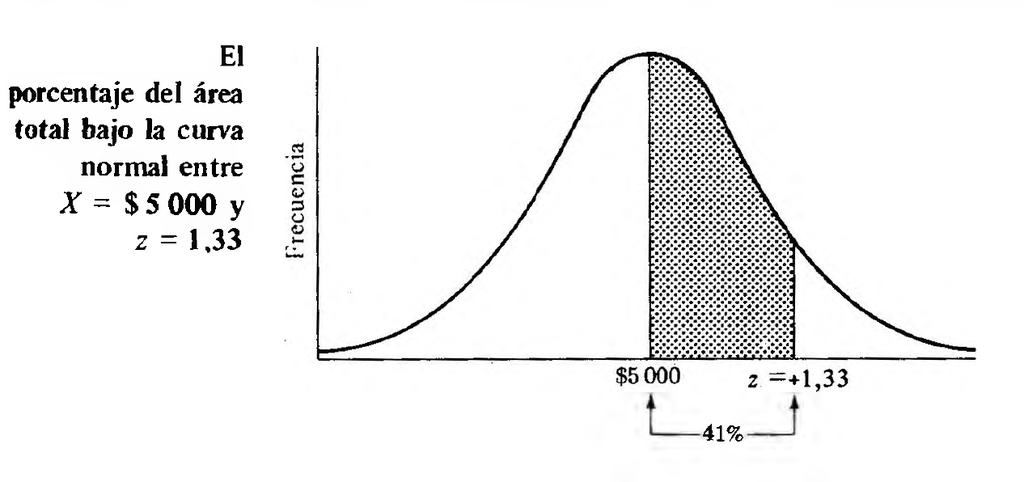

Fuente: Levin, 1999.

## Conceptos centrales

- Curva Normal.
- Puntajes crudos x.
- Puntajes z (z-score).
- Funciones de densidad.
- Área bajo la curva (AUC en inglés).

Iniciemos generando un set de datos aleatorios, de `n=50` de una distribución normal con promedio en 50 y desviación estándar en 12.5, para evaluar los conceptos centrales.

```r
# Cargar bibliotecas de trabajo
library(dplyr)
library(ggplot2)


# se generan datos en distribución normal con inicio fijo set.seed()
set.seed(2020)

# Datos de distribución normal con promedio en 50 y desviación estándar en 12.5
datos1 <- rnorm(50, mean = 50, sd=12.5)
datos1
```

```
##  [1] 54.71215 53.76935 36.27471 35.86993 15.04332 59.00717 61.73901 47.13278
##  [9] 71.98914 51.46708 39.33596 61.36574 64.95466 45.35520 48.45925 72.50054
## [17] 71.29995 12.01544 21.38781 50.72879 77.17957 63.72728 53.97775 49.08566
## [25] 60.42836 52.48438 66.22302 61.70898 48.15709 51.38040 39.84369 40.70372
## [33] 63.69181 80.44217 54.85148 53.63285 46.43002 50.95018 42.99627 55.58985
## [41] 61.35626 43.68676 46.23745 40.92455 35.24904 53.16343 45.36611 50.27724
## [49] 58.25055 56.10992
```

```r
# se imprimen los datos de forma ordenada con funcion sort()
sort(datos1)
```

```
##  [1] 12.01544 15.04332 21.38781 35.24904 35.86993 36.27471 39.33596 39.84369
##  [9] 40.70372 40.92455 42.99627 43.68676 45.35520 45.36611 46.23745 46.43002
## [17] 47.13278 48.15709 48.45925 49.08566 50.27724 50.72879 50.95018 51.38040
## [25] 51.46708 52.48438 53.16343 53.63285 53.76935 53.97775 54.71215 54.85148
## [33] 55.58985 56.10992 58.25055 59.00717 60.42836 61.35626 61.36574 61.70898
## [41] 61.73901 63.69181 63.72728 64.95466 66.22302 71.29995 71.98914 72.50054
## [49] 77.17957 80.44217
```

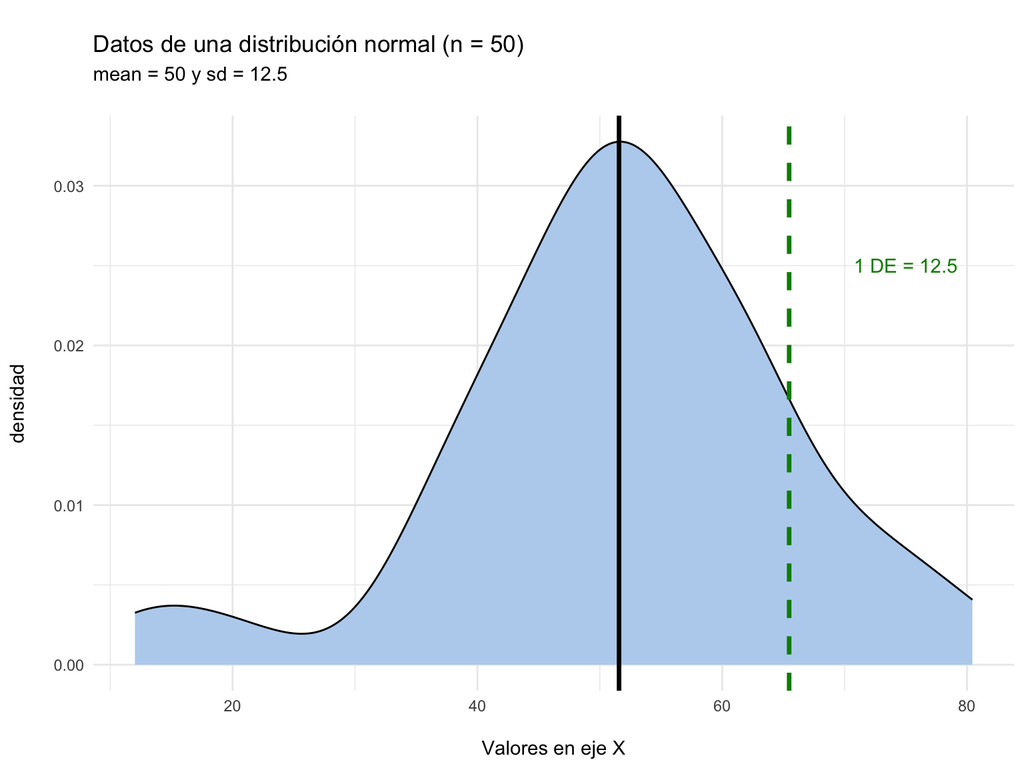

```r
# Se grafican los datos
ggplot() + aes(datos1) +
  geom_density(fill="slategray2") +
  geom_vline(xintercept = mean(datos1), size=1.2) +
  geom_vline(xintercept = (mean(datos1) + sd(datos1)), linetype=2, size=1.2, color="green4") +
  annotate("text", x = 75, y = 0.025, label = "1 DE = 12.5", color="green4") +
  labs(title = "\nDatos de una distribución normal (n = 50)",
       subtitle = "mean = 50 y sd = 12.5\n",
       x = "\nValores en eje X",
       y = "densidad\n") +
  theme_minimal()
```

```r
datos1
```

```
##  [1] 54.71215 53.76935 36.27471 35.86993 15.04332 59.00717 61.73901 47.13278
##  [9] 71.98914 51.46708 39.33596 61.36574 64.95466 45.35520 48.45925 72.50054
## [17] 71.29995 12.01544 21.38781 50.72879 77.17957 63.72728 53.97775 49.08566
## [25] 60.42836 52.48438 66.22302 61.70898 48.15709 51.38040 39.84369 40.70372
## [33] 63.69181 80.44217 54.85148 53.63285 46.43002 50.95018 42.99627 55.58985
## [41] 61.35626 43.68676 46.23745 40.92455 35.24904 53.16343 45.36611 50.27724
## [49] 58.25055 56.10992
```

```r
# Se corroboran los parámetros
prom <- mean(datos1)
prom
```

```
## [1] 51.57028
```

```r
de <- sd(datos1)
de
```

```
## [1] 13.89987
```

```r
# ¿Cuántos datos hay entre promedio y 1DE (una cola)? (deberían ser 34,13%)

datos_df <- data.frame(datos1) %>% rename(x = datos1)

de1_df <- datos_df %>% filter(x >= prom & x <= (prom + de))
nrow(de1_df)
```

```
## [1] 19
```

```r
# ¿Qué porcentaje son?
paste(nrow(de1_df) / length(datos1) * 100, "%")
```

```
## [1] "38 %"
```

**¿Por qué los datos de promedio y desviación estándar no son iguales?**

Porque son una muestra de números generados al azar en una distribución normal. Para lograr la distribución normal casi perfecta hay que aumentar la cantidad de muestras. **La ley de los grandes números** dice que conforme más grande son las muestras más se acercará a la distribución normal perfecta. Una prueba ahora con un millón de datos en lugar de 50.

Ahora procedemos a generar otro set de datos aleatorios, de `n=1.000.000` de una distribución normal con promedio en 50 y desviación estándar en 12.5

```r
# se generan datos en distribución normal de numeros aleatorios (random norm) con inicio fijo set.seed()
set.seed(2020)
datos2 <- rnorm(1000000, mean = 50, sd=12.5)


# se imprimen los datos de forma ordenada con funcion sort()
head(sort(datos2))
```

```
## [1] -8.834415 -8.674425 -8.077567 -7.241888 -6.200866 -5.274805
```

```r
tail(sort(datos2))
```

```
## [1] 105.7016 106.5538 107.3465 108.6684 109.3704 110.3419
```

```r
# RANGOS
min(datos1)
```

```
## [1] 12.01544
```

```r
min(datos2)
```

```
## [1] -8.834415
```

```r
max(datos1)
```

```
## [1] 80.44217
```

```r
max(datos2)
```

```
## [1] 110.3419
```

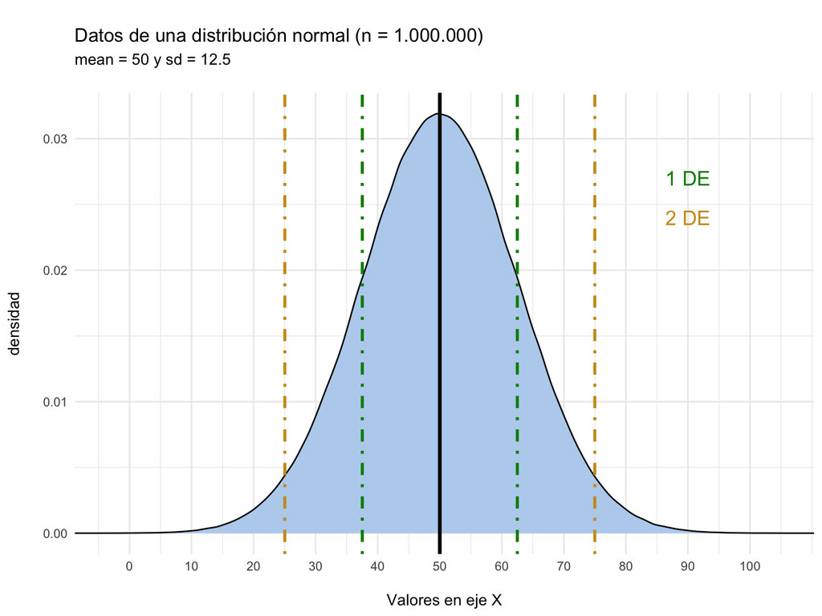

```r
# Se grafican los datos
ggplot() +
  aes(datos2) +
  geom_density(fill="slategray2") +
  geom_vline(xintercept = mean(datos2), size=1.2) +
  geom_vline(xintercept = (mean(datos2) + sd(datos2)), linetype=4, size=1, color="green4") +
  geom_vline(xintercept = (mean(datos2) - sd(datos2)), linetype=4, size=1, color="green4") +
  annotate("text", x = 90, y = 0.027, label = "1 DE", color="green4", size=5) +
  geom_vline(xintercept = (mean(datos2) + 2*sd(datos2)), linetype=4, size=1, color="goldenrod3") +
  geom_vline(xintercept = (mean(datos2) - 2*sd(datos2)), linetype=4, size=1, color="goldenrod3") +
  annotate("text", x = 90, y = 0.024, label = "2 DE", color="goldenrod3", size=5) +
  scale_x_continuous(expand = c(0,0), breaks = seq(0,100, 10)) +
  labs(title = "\nDatos de una distribución normal (n = 1.000.000)",
       subtitle = "mean = 50 y sd = 12.5\n",
       x = "\nValores en eje X",
       y = "densidad\n") +
  theme_minimal()
```

```r
# Se corroboran los parámetros
prom2 <- mean(datos2)
prom2
```

```
## [1] 50.00676
```

```r
de2 <- sd(datos2)
de2
```

```
## [1] 12.49015
```

```r
min(datos2)
```

```
## [1] -8.834415
```

```r
max(datos2)
```

```
## [1] 110.3419
```

```r
# ¿Cuántos datos hay entre promedio y 1DE (una cola)? (deberían ser 34,13%)
datos2_df <- data.frame(datos2) %>% rename(x = datos2)
head(datos2_df)
```

```
##          x
## 1 54.71215
## 2 53.76935
## 3 36.27471
## 4 35.86993
## 5 15.04332
## 6 59.00717
```

```r
# filtro
de1_df2 <- datos2_df %>% filter(x >= prom2 & x <= (prom2 + de2))
nrow(de1_df2)
```

```
## [1] 340610
```

```r
# ¿Qué porcentaje son?
paste(nrow(de1_df2) / length(datos2) * 100, "%")
```

```
## [1] "34.061 %"
```

**¿Cómo cambiaron los estadísticos y el gráfico de la curva normal?**

Interprete estos resultados.

# Puntajes crudos x y puntajes z (z-score)

## Ejercicio 1

Obtener el puntaje crudo de x = 60, siguiendo la ecuación: **z = (x - mean) / sd** donde:

- z = es el puntaje de desviación estándar que interesa calcular.
- x = es el puntaje crudo a evaluar.
- mean = promedio de todas las observaciones.
- sd = desviación estándar de todas las observaciones.

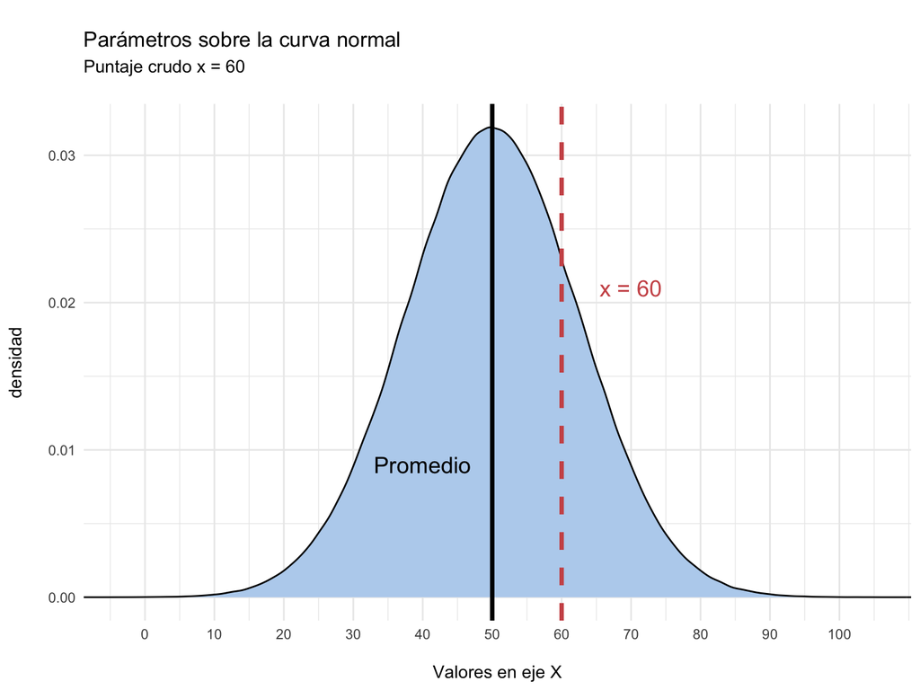

```r
## Se grafican los datos con el promedio y el valor de x = 60
ggplot() +
  aes(datos2) +
  geom_density(fill="slategray2") +
  geom_vline(xintercept = mean(datos2), size=1.3) +
  annotate("text", x = 40, y = 0.009, label = "Promedio",  size=5) +
  geom_vline(xintercept = 60, linetype = 2, color="indianred3", size=1.3) +
  annotate("text", x = 70, y = 0.021, label = "x = 60", color="indianred3", size=5) +
  scale_x_continuous(expand = c(0,0), breaks = seq(0,100, 10)) +
  labs(title = "\nParámetros sobre la curva normal",
       subtitle = "Puntaje crudo x = 60\n",
       x = "\nValores en eje X",
       y = "densidad\n") +
  theme_minimal()
```

```r
# Se generan los mismos
set.seed(2020)
datos2 <- rnorm(1000000, mean = 50, sd=12.5)


# Ecuación z = (x - mean) / sd
x <- 60
x
```

```
## [1] 60
```

```r
prom_ej <- mean(datos2)
prom_ej
```

```
## [1] 50.00676
```

```r
de_ej <- sd(datos2)
de_ej
```

```
## [1] 12.49015
```

```r
z_score <- (x - prom_ej) / de_ej
z_score
```

```
## [1] 0.8000899
```

### Respuesta:

El puntaje crudo de 60 representa 0.80 desviaciones estándar por encima del promedio.

Esto también lo podemos comprobar de forma inversa: si sabemos el tamaño de la sd, y sabemos que el puntaje crudo está a 0.80 desviaciones estándar, entonces podemos obtener el puntaje crudo con la ecuación a partir del promedio de los datos (que también lo tenemos).

```r
# Ecuación: x = (z * sd) + mean
x_comprob <- (z_score * de_ej) + prom_ej
x_comprob
```

```
## [1] 60
```

Otra forma de comprobar lo anterior usando los conocimientos de números relativos aprendidos el semestre anterior.

Los datos generados de manera aleatoria responden a una distribución normal con promedio = 50 y desviación estándar = 12.5. Ya sabemos que el valor de x = 60 es igual a un z-score de 0.80 desviaciones estándar por encima del promedio. Entonces podemos calcularlo manualmente para comprobar que se cumple, multiplicando 0.8 por la desviación estándar para obtener la “fracción de desviación estándar” en valores de X a la que refiere el z-score. Y luego sumar esa fracción al promedio. El resultado correcto debe llevarnos al punto en X definido = 60.

```r
# El 0.8 de la desviación estándar es:
fraccion_sd <- 12.5 * 0.8
fraccion_sd
```

```
## [1] 10
```

```r
# promedio + fraccion_sd
valor_x <- prom_ej + fraccion_sd
valor_x
```

```
## [1] 60.00676
```

## Ejercicio 2

¿Cuál es la probabilidad de obtener un 60 en esta distribución normal? Lo que es lo mismo, cuál es el área de la curva acumulada hasta el z-score = 0.80. Esos datos se pueden obtener con la función pnorm(), la cual recibe el valor del punto crudo, el promedio y la desviacion estándar de la distribución normal.

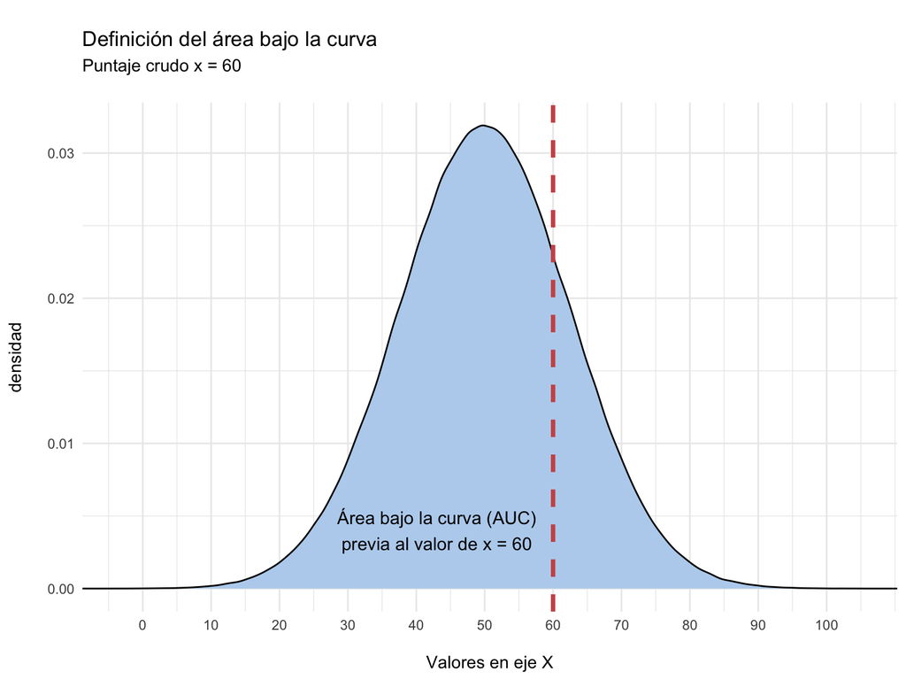

```r
# Se grafican los datos
ggplot() +
  aes(datos2) +
  geom_density(fill="slategray2") +
  geom_vline(xintercept = 60, color="indianred3", linetype = 2, size=1.3) +
  annotate("text", x = 43, y = 0.004, label = "Área bajo la curva (AUC)\nprevia al valor de x = 60",  size=4, color="black") +
  scale_x_continuous(expand = c(0,0), breaks = seq(0,100, 10)) +
  labs(title = "\nDefinición del área bajo la curva",
       subtitle = "Puntaje crudo x = 60\n",
       x = "\nValores en eje X",
       y = "densidad\n") +
  theme_minimal()
```

Se obtiene toda el área acumulada bajo la curva (AUC) de 0 hasta el puntaje crudo de x = 60. Para ello se usa la función `pnorm()` y el parámetro de `lower.tail = TRUE`.

```r
# Probabilidad completa con lower.tail = TRUE

pnorm(q = x, mean = prom_ej, sd = de_ej, lower.tail = TRUE)
```

```
## [1] 0.7881706
```

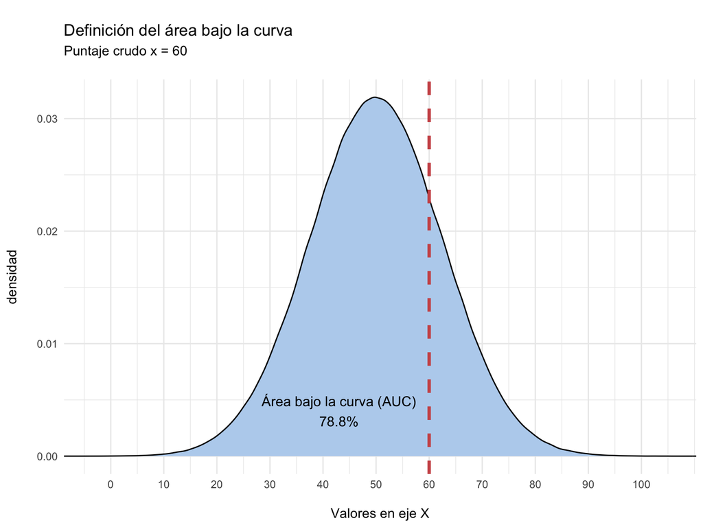

```r
ggplot() +
  aes(datos2) +
  geom_density(fill="slategray2") +
  geom_vline(xintercept = 60, color="indianred3", linetype = 2, size=1.3) +
  annotate("text", x = 43, y = 0.004, label = "Área bajo la curva (AUC)\n78.8%", color="black", size=4) +
  scale_x_continuous(expand = c(0,0), breaks = seq(0,100, 10)) +
  labs(title = "\nDefinición del área bajo la curva",
       subtitle = "Puntaje crudo x = 60\n",
       x = "\nValores en eje X",
       y = "densidad\n") +
  theme_minimal()
```

### Respuesta:

El área bajo la curva (AUC) acumulada hasta el puntaje de x = 60 es igual a 78,8%.

## Ejercicio 3

Obtener el área entre el promedio y el punto crudo de x = 60 (valor que aparece en Tabla B del libro). Esto se obtiene, restando 0.5 a la probabilidad completa obtenida anteriormente, dado que la probabilidad AUC hasta el promedio es de 50% (punto medio de una distribución normal), y el z-score está por encima del promedio.

```r
# el AUC entre el promedio y el valor de X = 60
pnorm(q = x, mean = prom_ej, sd = de_ej, lower.tail = TRUE) - 0.5
```

```
## [1] 0.2881706
```

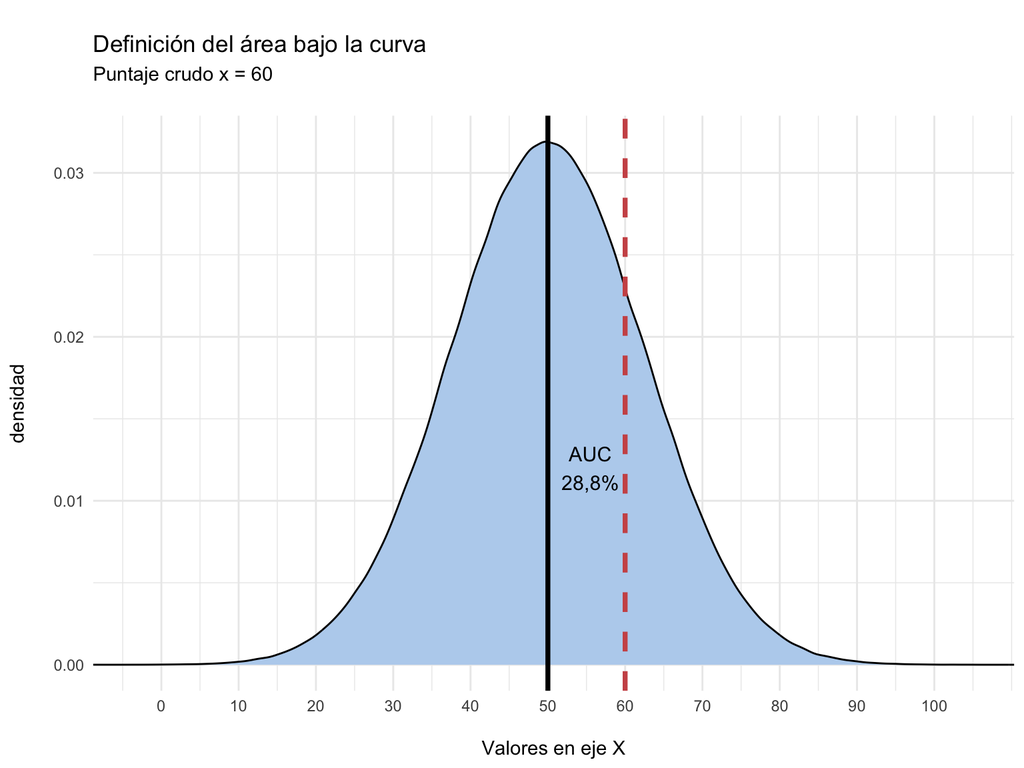

```r
# Se grafican los datos
ggplot() +
  aes(datos2) +
  geom_density(fill="slategray2") +
  geom_vline(xintercept = mean(datos2), color="black", linetype=1, size=1.3) +
  geom_vline(xintercept = 60, color="indianred3", linetype = 2, size=1.3) +
  annotate("text", x = 55.5, y = 0.012, label = "AUC\n28,8%", color="black", size=4) +
  scale_x_continuous(expand = c(0,0), breaks = seq(0,100, 10)) +
  labs(title = "\nDefinición del área bajo la curva",
       subtitle = "Puntaje crudo x = 60\n",
       x = "\nValores en eje X",
       y = "densidad\n") +
  theme_minimal()
```

### Respuesta:

El área bajo la curva (AUC) entre el promedio y el puntaje de x = 60 es igual a 28,81%. Esto se puede corroborar en la tabla B del libro de Levín y Levin (1999), revisando la probabilidad en un z-score = 0.80.

La tabla B del libro de Levin confirma el resultado obtenido. al revisar el z-score = 0.80 el resultado de la tabla es: 28.81.

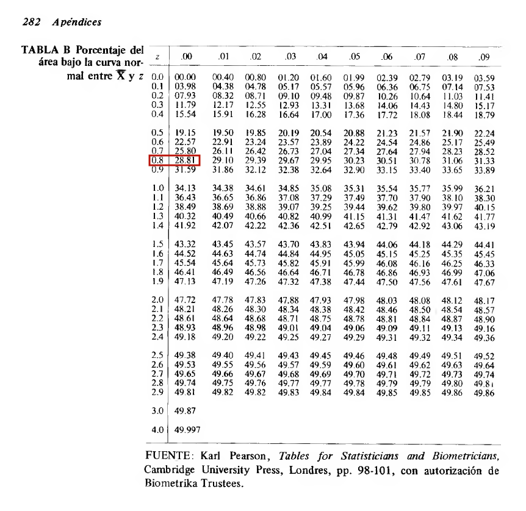

```r
knitr::include_graphics("Ejemplo_TablaB.png")
```

## Ejercicio 4

Obtener el área posterior, es decir la probabilidad de que sea mayor al punto crudo de x = 60.

Esto se obtiene también con la función `pnorm()` y el parámetro de `lower.tail = FALSE`, como se muestra a continuación.

```r
# SOLO el área posterior con lower.tail = FALSE
pnorm(60, mean = prom_ej, sd = de_ej, lower.tail = FALSE)
```

```
## [1] 0.2118294
```

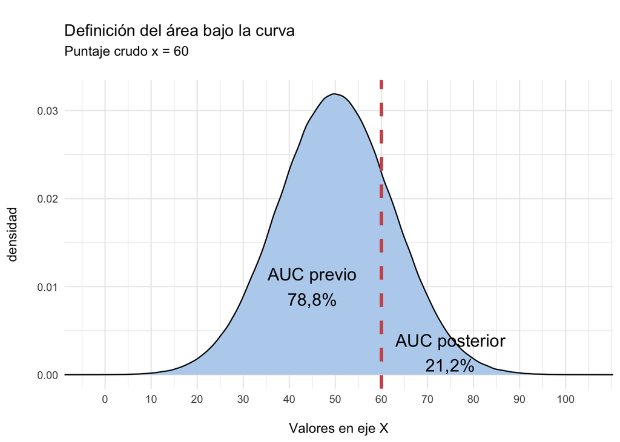

```r
# Se grafican los datos
ggplot() +
  aes(datos2) +
  geom_density(fill="slategray2") +
  geom_vline(xintercept = 60, color="indianred3", linetype=2, size=1.3) +
  annotate("text", x=45, y=0.01, label= "AUC previo\n78,8%", color="black", size=5) +
  annotate("text", x=75, y=0.0025, label= "AUC posterior\n21,2%", color="black", size=5) +
  scale_x_continuous(expand = c(0,0), breaks = seq(0,100, 10)) +
  labs(title = "\nDefinición del área bajo la curva",
       subtitle = "Puntaje crudo x = 60\n",
       x = "\nValores en eje X",
       y = "densidad\n") +
  theme_minimal()
```

### Respuesta:

El área bajo la curva (AUC) posterior al puntaje de x = 60 es igual a 21,2%.

Esto tiene todo el sentido. Si se suma el AUC entre el promedio y el puntaje crudo (28,8%) y el AUC posterior al puntaje crudo (21,2%), se obtiene el área de la mitad de la distribución normal, es decir el 50% de los datos.

```r
# el AUC entre el promedio y el valor de X = 60
pnorm(q = x, mean = prom_ej, sd = de_ej, lower.tail = TRUE) - 0.5
```

```
## [1] 0.2881706
```

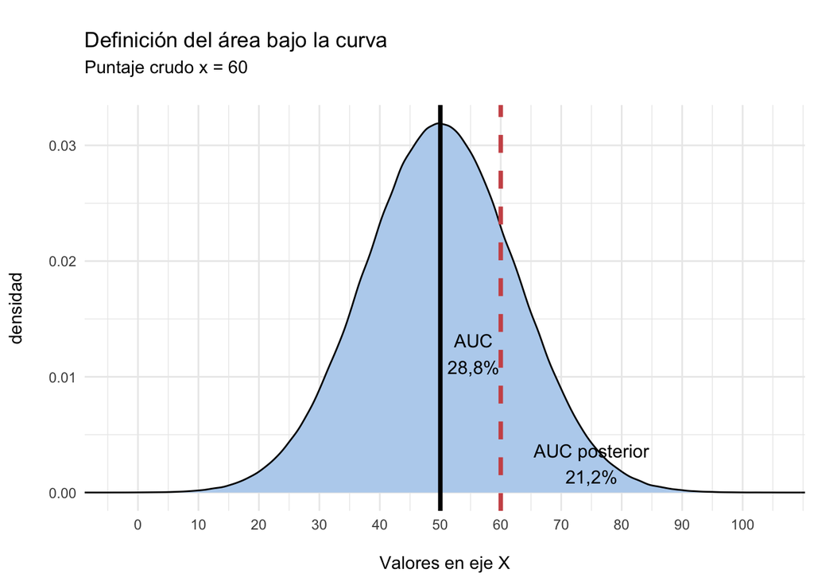

```r
# Se grafican los datos
ggplot() +
  aes(datos2) +
  geom_density(fill="slategray2") +
  geom_vline(xintercept = mean(datos2), color="black", linetype=1, size=1.3) +
  geom_vline(xintercept = 60, color="indianred3", linetype = 2, size=1.3) +
  annotate("text", x = 55.5, y = 0.012, label = "AUC\n28,8%", color="black", size=4) +
  annotate("text", x=75, y=0.0025, label= "AUC posterior\n21,2%", color="black", size=4) +
  scale_x_continuous(expand = c(0,0), breaks = seq(0,100, 10)) +
  labs(title = "\nDefinición del área bajo la curva",
       subtitle = "Puntaje crudo x = 60\n",
       x = "\nValores en eje X",
       y = "densidad\n") +
  theme_minimal()
```

## Ejercicio 5

¿Cuál es la probabilidad de obtener un valor dentro de dos desviaciones estándar? Y entonces ¿cuál es la probabilidad de obtener un valor que esté por fuera de las dos desviaciones estándar?

Las respuestas a esas dos preguntas son claves para entender el tema de prueba de hipótesis y los valores de significacia de muchas pruebas estadísticas. Lo que se conoce como el p-value. Primero es necesario obtener las respuestas con base en lo que ya aprendimos.

Siguiendo el código de R, podemos obtener:

```r
# probabilidad de obtener un valor dentro de dos desviaciones estándar: por encima y por debajo del promedio
P_2DE_2tail <- ((pnorm(1.96, lower.tail = TRUE)) - 0.5) * 2
P_2DE_2tail
```

```
## [1] 0.9500042
```

```r
# probabilidad de obtener un valor fuera de las dos desviaciones estándar
p_value <- 1 - P_2DE_2tail
p_value
```

```
## [1] 0.04999579
```

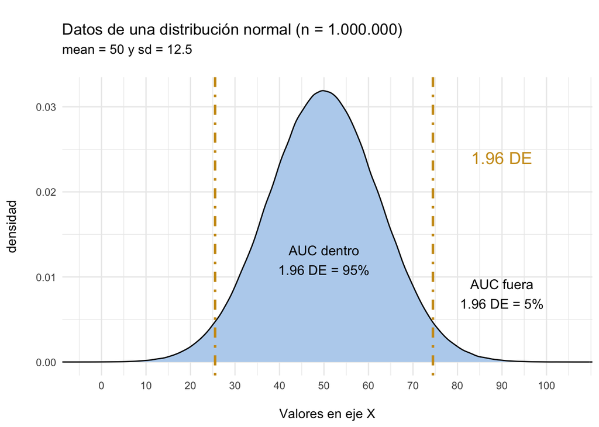

```r
# Se grafican los datos
ggplot() +
  aes(datos2) +
  geom_density(fill="slategray2") +
  geom_vline(xintercept = (mean(datos2) + 1.96*sd(datos2)), linetype=4, size=1, color="goldenrod3") +
  geom_vline(xintercept = (mean(datos2) - 1.96*sd(datos2)), linetype=4, size=1, color="goldenrod3") +
  annotate("text", x = 90, y = 0.024, label = "1.96 DE", color="goldenrod3", size=5) +
  annotate("text", x = 50, y = 0.012, label = "AUC dentro\n1.96 DE = 95%", color="black", size=4) +
  annotate("text", x=90, y=0.008, label= "AUC fuera\n1.96 DE = 5%", color="black", size=4) +
  scale_x_continuous(expand = c(0,0), breaks = seq(0,100, 10)) +
  labs(title = "\nDatos de una distribución normal (n = 1.000.000)",
       subtitle = "mean = 50 y sd = 12.5\n",
       x = "\nValores en eje X",
       y = "densidad\n") +
  theme_minimal()
```

## Ejercicio 6: en clase

Las mujeres de los Países Bajos tienen una estatura promedio de 170 cms con una desviación estándar hipotética de 15 cms. Genere una secuencia de datos al azar de 1.000.000 de datos con promedio = 170 cms, y desviación estándar de 15cms. ¿Calcule cuál es la probabilidad de obtener mujeres con la siguiente estatura?

- 10 cms por encima o por debajo del promedio. ¿Cuáles son esos valores?
- 20 cms por encima o por debajo del promedio. ¿Cuáles son esos valores?

Las mujeres de Guatemala tienen una estatura promedio de 150 cms con una desviación estándar hipotética de 15 cms. Genere una secuencia de datos al azar de 1.000.000 de datos con promedio = 150 cms, y desviación estándar de 15cms. ¿Calcule cuál es la probabilidad de obtener mujeres con la siguiente estatura?

- 10 cms por encima o por debajo del promedio. ¿Cuáles son esos valores?
- 20 cms por encima o por debajo del promedio. ¿Cuáles son esos valores?

Analice los resultados comparados.

# Diferencia de medias (prueba z y prueba t)

De acuerdo con Levin (1999), la mayoría de los investigadores sociales se interesan en la tarea de contrastar las hipótesis que existen acerca de las diferencias entre dos o más muestras. Cuando comprueban diferencias entre las muestras, los investigadores sociales se hacen preguntas tales como: ¿Difieren los alemanes de los norteamericanos con respecto a la obediencia a la autoridad? ¿Quién presenta una tasa de suicidios más alta, los católicos o los protestantes? ¿Qué efecto producen los entrevistadores negros frente a los blancos sobre la honestidad de los entrevistados negros? ¿Las personas políticamente conservadoras disciplinan más severamente a sus niños que las personas políticamente liberales?. Nótese que cada pregunta de investigación implica hacer una comparación entre dos grupos: conservadores frente a liberales, entrevistadores negros frente a entrevistadores blancos; protestantes frente a católicos; alemanes frente a norteamericanos.

El proceso para comprobar diferencia entre dos muestra implica la elaboración de una hipótesis nula (H0) y una hipotesis alternativa (H1), también llamada hipótesis de investigación.

En el análisis estadístico se ha vuelto convencional empezar con la comprobación de la hipótesis nula —la hipótesis que sustenta que dos muestras han sido extraídas de la misma población. De acuerdo con la hipótesis nula, cualquier diferencia observada entre las muestras se considera como un hecho casual resultante únicamente del error de muestreo. Por lo tanto, la diferencia que existe entre dos medias muéstrales no representa una diferencia real entre sus medias poblacionales. Debe notarse que la hipótesis nula no niega la posibilidad de obtener diferencias entre medias muéstrales. Al contrario, busca explicar tales diferencias entre las medias muéstrales atribuyéndolas a la operación del error de muestreo.

La hipótesis nula se expone generalmente (aunque no necesariamente) con la esperanza de ser rechazada. Esto ocurre cuando no existe información suficiente para comprobar que las medias de ambas muestras son iguales. Esto tiene sentido, ya que la mayoría de los investigadores sociales busca establecer diferencias entre distintas poblaciones.

Si no existe información para comprobar la hipótesis nula (H0) en nuestro experimento, se rechaza. En ese caso se toma la hipótesis alternativa (H1) como válida, que plantea que sí existe una verdadera diferencia poblacional entre ambas muestras. Se afirma, entonces, que la diferencia obtenida entre medias muéstrales es demasiado grande como para ser explicada por el error de muestreo.

## Niveles de confianza

Para establecer si nuestra diferencia muestral obtenida es estadísticamente significativa —resultado de una diferencia poblacional real y no sólo del error de muestreo- se acostumbra establecer un nivel de confianza (también conocido como nivel de significancia), nivel de probabilidad en el cual se puede rechazar a la hipótesis nula y se puede aceptar con confianza la hipótesis de investigación.

Es un asunto convencional utilizar el nivel de confianza de 0,05. O sea que estamos dispuestos a rechazar la hipótesis nula si una diferencia muestral obtenida ocurre casualmente sólo 5 veces o menos entre 100 (5 por ciento). El nivel de confianza de 0,05 se ha representado gráficamente en la Figura 4. Como se muestra allí, el nivel de confianza de 0,05 se encuentra en las pequeñas áreas de las “colas” de la distribución de diferencias de medias. Estas son las áreas bajo la curva que representan una distancia de más o menos 1,96 desviaciones estándar de una diferencia media de cero.

**Figura 4**

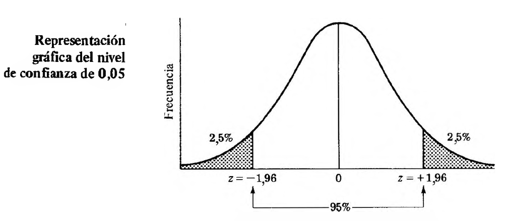

Fuente: Levin, 1999.

Para comprender mejor por qué este punto en particular de la distribución muestral representa el nivel de confianza de 0,05 podríamos volver a la Tabla B, al final del texto, para determinar el porcentaje de frecuencia total asociado con 1,96 desviaciones estándar de la media. Vemos que 1,96 desviaciones estándar en una u otra dirección representan el 2,5% de las diferencias entre medias muéstrales (50% — 47,5% = 2,5% ). En otras palabras, el 95 por ciento de las diferencias muéstrales cae entre —1.96 DE y + 1.96 DE de una diferencia media de cero; sólo el 5 por ciento cae en este punto o más allá de él (2,5% + 2,5% = 5%).

Los niveles de confianza pueden establecerse para cualquier grado de probabilidad. Por ejemplo, un nivel de confianza más estricto es el nivel de confianza de 0,01, por medio del cual se rechaza la hipótesis nula si solamente hay 1 oportunidad entre 100 de que la diferencia muestral obtenida pueda ocurrir por error de muestreo (1 por ciento).

Los niveles de confianza no nos dan una afirmación absoluta acerca de la corrección de la hipótesis nula. Siempre que decidamos rechazar la hipótesis nula a un cierto nivel de confianza, nos abriremos a la posibilidad de tomar la decisión equivocada. Rechazar la hipótesis nula cuando se debería aceptar se conoce como el **error alpha (o error tipo I)**. La probabilidad de cometer el error alpha sólo puede surgir cuando rechazamos la hipótesis nula y varía de acuerdo con el nivel de confianza que escojamos.

Sin embargo, mientras más cerca de la cola de la curva caiga nuestro nivel de confianza, mayor será el riesgo de cometer otra clase de error, conocido como el **error beta (o error tipo II)**, error en el que se cae al aceptar la hipótesis nula cuando debió haber sido rechazada. El error beta indica que nuestra hipótesis de investigación puede ser aún correcta, a pesar de la decisión de rechazarla y de aceptar la hipótesis nula. Un método para reducir el riesgo de cometer el error beta es aumentar el tamaño de las muestras de manera que sea más probable que quede representada una diferencia poblacional real.

## Procedimiento y código

La diferencia de medias puede ser utilizada para muestras con distintas características. Las más comunes son:

1. diferencia entre dos muestras grandes (prueba z)
2. diferencia entre dos muestras pequeñas (prueba t)
3. diferencia entre dos muestras de distinto tamaño
4. diferencia entre dos mediciones de la misma muestra en tiempos distintos (panel)

En general, hay seis pasos para establecer la diferencia de medias, y hacer la comprobación de la hipótesis nula (H0) y la alternativa (H1). El procedimiento y las fórmulas varía según el tipo de muestras que se trabaje. Acá se presenta el procedimiento para los casos 1 y 2. El libro de Levin (1999) usado en este documento, detalla las variaciones en las fórmulas para los casos 3 y 4.

**PASO #1:** Encontrar la media para cada muestra

$$\begin{equation*}
\bar{X}_{1}=\frac{\sum X_{1}}{N} ~~~~~~~ \bar{X}_{2}=\frac{\sum
X_{2}}{N}
\end{equation*}$$

**PASO #2:** Encontrar la desviación estándar para cada muestra

$$\begin{equation*}
s_{1}=\sqrt{\frac{\sum X_{1}^{2}}{N}-\bar{X}_{1}^{2}} ~~~~~~~
s_{2}=\sqrt{\frac{\sum X_{2}^{2}}{N}-\bar{X}_{2}^{2}}
\end{equation*}$$

**PASO #3:** Encontrar el error estándar de cada media

$$\begin{equation*}
\sigma_{\bar{X}1}=\frac{s_{1}}{\sqrt{N-1}} ~~~~~~~
\sigma_{\bar{X}2}=\frac{s_{2}}{\sqrt{N-1}}
\end{equation*}$$

**PASO #4:** Encontrar el error estándar de la diferencia

$$\begin{equation*}
\sigma_{dif}=\sqrt{\sigma_{\bar{X}1}^{2}+\sigma_{\bar{X}2}^{2}}
\end{equation*}$$

**PASO #5:** Convertir la diferencia entre medias muestrales a unidades de error estándar de la diferencia (valor z) para muestras grandes. Para muestras pequeñas obtener la razón t.

**Valor z para muestras grandes**

$$\begin{equation*}
z=\frac{\bar{X}_{1}-\bar{X}_{2}}{\sigma_{dif}}
\end{equation*}$$

**Razón t para muestras pequeñas**

En caso de muestras pequeñas, debe calcularse la **razón t**. Cuando la muestra de datos es pequeña, las premisas de la distribución normal no se cumplen de la misma forma. Para compensar estadísticamente este alejamiento de la normalidad, en la distribución de diferencias, obtenemos en su lugar lo que se conoce comúnmente como la razón t. AI igual que el puntaje z, la razón t puede usarse para convertir una diferencia entre medias muéstrales a unidades de error estándar de la diferencia. También de la misma manera en que se llega al puntaje z obtenemos una razón t, tomando la diferencia entre nuestras medias muestrales y dividiéndolas por nuestro error estándar de la diferencia. Por fórmula:

$$\begin{equation*}
t=\frac{\bar{X}_{1}-\bar{X}_{2}}{\sigma_{dif}}
\end{equation*}$$

Como se muestra arriba, la fórmula de la razón t es idéntica a la fórmula para el puntaje z que aprendimos anteriormente. Sin embargo, a diferencia de un puntaje z, la razón t debe interpretarse con referencia a los grados de libertad (gl). Para calcular los grados de libertad de una muestra pequeña se sigue la fórmula:

$$\begin{equation*}
gl=N_{1}+N_{2}-2
\end{equation*}$$

donde

$N_{1}$ = el tamaño de la primera muestra

$N_{2}$ = el tamaño de la segunda muestra

Podemos interpretar cualquier razón t que obtengamos con la ayuda de la Tabla de valores T (tabla 2), y del número de grados de libertad que hemos calculado. La Tabla 2 proporciona los valores de t que se requieren para rechazar la hipótesis nula a los niveles de confianza de 0,05 y 0,01 para varios grados de libertad. La tabla incluye una columna marcada gl (grados de libertad) y una lista de valores t para cada grado de libertad a los niveles de confianza de 0,05 y 0,01. Como veremos, estos valores t pueden usarse para interpretar la razón t que hemos calculado (t-experimental). Si nuestra t-experimental es mayor que la razón t de la tabla, entonces se rechaza la hipótesis nula (H0), y se acepta la alternativa (H1).

**Tabla 2.1. Razón t**

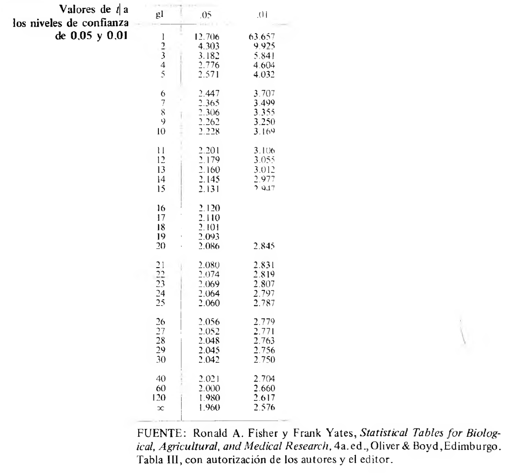

Fuente: Levin, 1999.

Asimismo con la tabla B del libro de Levin (1999) se obtienen los valores para la prueba z teóricos, que son utilizados para contrastar con los valores z obtenidos por los análisis con las muestras de investigación.

**Tabla 2.2. Razón z**

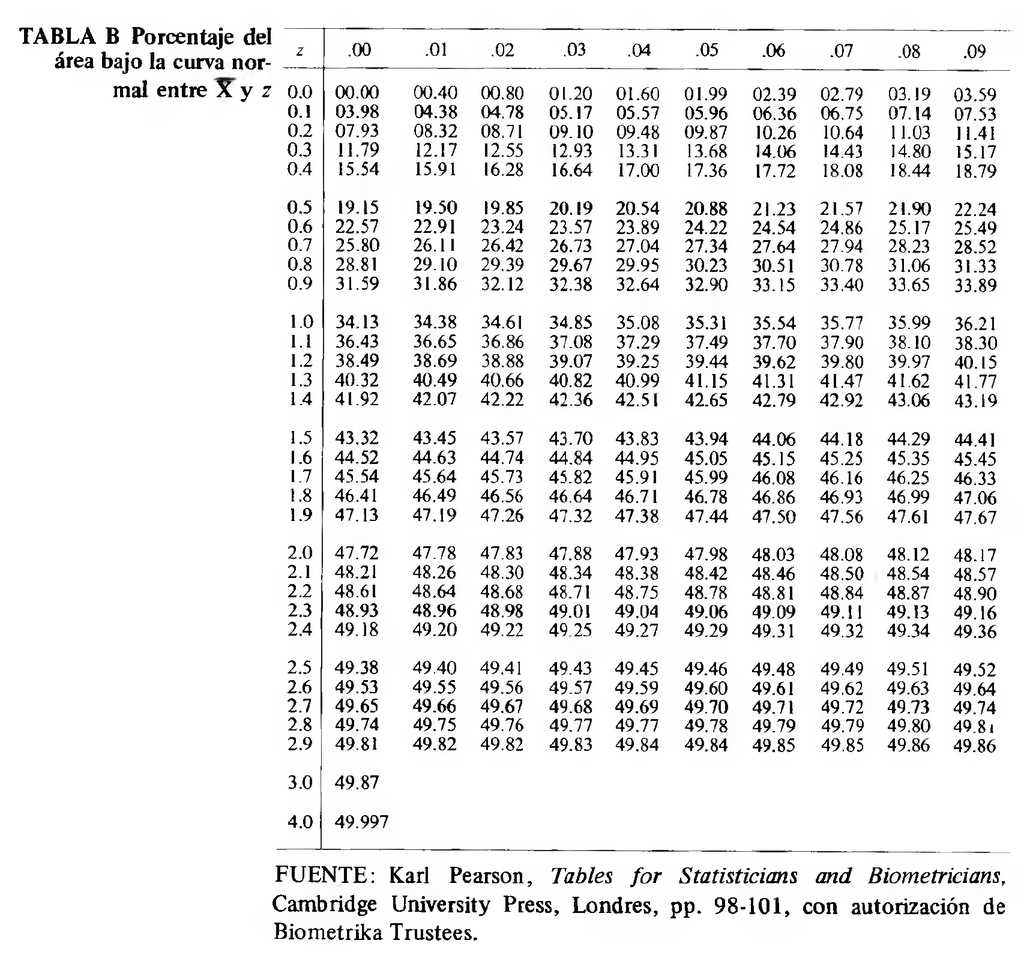

Fuente: Levin, 1999.

**PASO #6:** Comparar el valor z (para muestras grandes) en la tabla de valores Z, o la razón t (para muestras pequeñas) en la tabla de valores T, para determinar si se comprueba o se rechaza la hipótesis nula.

- En el caso de **muestras grandes** se busca el `valor z` obtenido en el paso #5 en la tabla de valores Z. Con un nivel de significancia de P=0,05 si el valor obtenido en la tabla, para ambos lados de la curva normal, es mayor a 0,95 significa que el valor se sitúa en “las colas” de la distribución y por ende es un valor extremo. Con eso podemos concluir, con un 95% de confianza, que las medias de las dos muestras analizadas son distintas. En tal sentido, se rechaza la hipótesis nula que indica que las medias son iguales, y se acepta la hipótesis alternativa que concluye que sí hay diferencias significativas entre las medias.
- En el caso de **muestras pequeñas** se compara la razón t-experimental con la razón t-apropiada de la tabla de valores T, al nivel de significancia de interés: P=0,05 o bien P=0,01. Si nuestra t-experimental es mayor que la t-apropiada, se rechaza la hipótesis nula, es decir, existe evidencia para determinar que las poblaciones no son iguales y entonces se acepta la hipótesis alternativa.

## Ejemplo de prueba z

Este es un ejemplo de comprobación de diferencias de medias, con base en el libro de Levin (1999), del curso Análisis Político Cuantitativo II, del 2020.

### Prueba hipótesis

H0 = no hay diferencias en etnocentrismo entre hombres y mujeres

H1 = sí hay diferencias en etnocentrismo entre hombres y mujeres

### Comprobación de hipótesis

#### Creación de datos

```r
# se cargan las bibliotecas y datos
library(dplyr)
library(ggplot2)

datos <- data.frame(hombre = c(rep(1,21), rep(2,7), rep(3,4), rep(4,2), 5),
                    mujer = c(rep(1,23), rep(2,8), rep(3,2), 4, 5))

head(datos)
```

```
##   hombre mujer
## 1      1     1
## 2      1     1
## 3      1     1
## 4      1     1
## 5      1     1
## 6      1     1
```

```r
tail(datos)
```

```
##    hombre mujer
## 30      3     2
## 31      3     2
## 32      3     3
## 33      4     3
## 34      4     4
## 35      5     5
```

#### Paso previo:

Se calculan el total observaciones, las observaciones al cuadrado y las sumas de todas las observaciones

```r
#Acá se establecen el total de observaciones para cada muestra

n_h <- nrow(datos)
n_h
```

```
## [1] 35
```

```r
n_m <- nrow(datos)
n_m
```

```
## [1] 35
```

```r
#Acá se eleva al cuadrado cada observación según muestra

datos$hombreCuad <- datos$hombre^2

datos$mujerCuad <- datos$mujer^2

head(datos)
```

```
##   hombre mujer hombreCuad mujerCuad
## 1      1     1          1         1
## 2      1     1          1         1
## 3      1     1          1         1
## 4      1     1          1         1
## 5      1     1          1         1
## 6      1     1          1         1
```

```r
tail(datos)
```

```
##    hombre mujer hombreCuad mujerCuad
## 30      3     2          9         4
## 31      3     2          9         4
## 32      3     3          9         9
## 33      4     3         16         9
## 34      4     4         16        16
## 35      5     5         25        25
```

```r
#Acá se hacen en un solo objeto las sumas de las observaciones simples para cada muestra
# y luego la suma de las observaciones al cuadrado para cada muestra.

suma_hombre <- sum(datos$hombre)
suma_hombre
```

```
## [1] 60
```

```r
suma_mujer <- sum(datos$mujer)
suma_mujer
```

```
## [1] 54
```

```r
suma_hombreCuad <- sum(datos$hombreCuad)
suma_hombreCuad
```

```
## [1] 142
```

```r
suma_mujerCuad <- sum(datos$mujerCuad)
suma_mujerCuad
```

```
## [1] 114
```

#### Paso 1:

Media de las muestras

```r
media_hombre <- suma_hombre / n_h
media_hombre
```

```
## [1] 1.714286
```

```r
media_mujer <- suma_mujer / n_m
media_mujer
```

```
## [1] 1.542857
```

```r
# Diferencia entre medias
dif_medias <- media_hombre - media_mujer
dif_medias
```

```
## [1] 0.1714286
```

#### Paso 2:

Desviación estándar de las muestras

```r
s_hombre <- sqrt((suma_hombreCuad / n_h) - (media_hombre^2))
s_hombre
```

```
## [1] 1.057529
```

```r
s_mujer <- sqrt((suma_mujerCuad / n_m) - (media_mujer^2))
s_mujer
```

```
## [1] 0.9363411
```

#### Paso 3:

Error estándar de las medias

```r
error_hombre <- s_hombre / sqrt((n_h - 1))
error_hombre
```

```
## [1] 0.1813647
```

```r
error_mujer <- s_mujer / sqrt((n_m - 1))
error_mujer
```

```
## [1] 0.1605812
```

#### Paso 4:

Error estándar de la diferencia de las medias

```r
error_dif <- sqrt((error_hombre^2) + (error_mujer^2))
error_dif
```

```
## [1] 0.2422385
```

#### Paso 5:

Puntaje Z. Nótese que el puntaje Z obtenido en este ejercicio varía levemente del valor del libro (0,68). Eso se explica porque el código en R contiene los procesamientos con todos lo decimales, lo cuál hace el resultado más exacto. En el libro se usan datos redondeados. Para este ejemplo se utilizan los datos según lo indican los procesamientos con decimales, por ello puede no coincidir por completo con el libro de Levin (1999).

```r
z_punt <- (media_hombre - media_mujer) / error_dif
z_punt
```

```
## [1] 0.7076852
```

#### Paso 6:

Area bajo la curva (AUC)

```r
# Usando código para obtener el AUC
auc <- (pnorm(z_punt, lower.tail = TRUE) - 0.5) * 2
auc
```

```
## [1] 0.5208592
```

```r
# RECORDAR que también se puede ver la Tabla de Valores Z:

# Puntaje Z = 0,70 es igual a un 25,80% en la tabla de valores Z.
# Eso se multiplica por dos para tener el área bajo la curva de los dos lados
# (varía levemente por los decimales)

auc_tabla <- 25.80 *2
auc_tabla
```

```
## [1] 51.6
```

#### Paso 7:

Se obtiene el p-value: área fuera del AUC

```r
# p-value
p_value <- 1 - auc
p_value
```

```
## [1] 0.4791408
```

```r
# Siguiendo el procedmiento de la Tabla B de Valores Z (varía levemente por los decimales):
p_value_tabla <- 100 - auc_tabla
p_value_tabla
```

```
## [1] 48.4
```

**Gráfico**

Representación gráfica del Área Bajo la Curva de la prueba de hipótesis del ejemplo (AUC-PH). En este caso el AUC-PH = 0.52. Eso es, dentro de la zona del centro del gráfico donde se confirma la hipótesis nula (H0).

```r
# Líneas del gráfico para definir el AUC
auc_dosColas <- auc/2
auc_dosColas
```

```
## [1] 0.2604296
```

[figure not shown]

```r
set.seed(2020)
df_grafico <- data.frame(data = rnorm(1000000, mean = 0, sd=0.2375))


# gráfico
ggplot(df_grafico, aes(x=data)) +
  geom_density(fill="slategray2") +
  geom_vline(xintercept = (mean(df_grafico$data) + 2*sd(df_grafico$data)), linetype=1, size=1, color="goldenrod3") +
  geom_vline(xintercept = (mean(df_grafico$data) - 2*sd(df_grafico$data)), linetype=1, size=1, color="goldenrod3") +
  geom_vline(xintercept = 0, linetype=3, size=1, color="grey60") +
  geom_vline(xintercept = auc_dosColas, linetype=2, size=1, color="purple") + # agrega línea derecha del AUC
  geom_vline(xintercept = -auc_dosColas, linetype=2, size=1, color="purple") + # agrega línea izquierda del AUC
  annotate("rect", xmin = -auc_dosColas, xmax = auc_dosColas, ymin = -Inf, ymax = Inf, alpha = .2, fill="purple") + # agrega rectángulo del AUC
  annotate("text", x = 0.1, y = 1.6, label = "AUC-PH = 0.52", color="purple", size=5) + # agrega texto del AUC
  annotate("text", x = 1.535, y = 0.25, label = "1.96 DE", color="goldenrod3", size=5) +
  annotate("text", x = 0, y = 0.5, label = "AUC dentro\n1.96 DE = 0.95", color="black", size=4, fontface="bold") +
  annotate("text", x=0.6, y=0.25, label= "AUC fuera\n1.96 DE = 0.05", color="tomato3", size=4, fontface="bold") +
  scale_x_continuous(expand = c(0,0), breaks = seq(-1,1, 0.1), limits = c(-1, 1)) +
  labs(title = "\nDatos de una distribución normal (n = 1.000.000)",
       subtitle = "mean = 0 y sd = 4.75\n",
       x = "\nValores en eje X",
       y = "densidad\n") +
  theme_minimal()
```

#### Paso 8:

Interpretación resultados

Nivel confianza = 95%

valor z = 0.7076852

AUC = 0.520

p_vale = 0.479

Dado que `p_value > 0.05`, se mantiene la hipótesis nula. Otra forma de interpretarlo es: dado que el `auc < 0,95`, se mantiene la hipótesis nula. Por consiguiente, no hay diferencias entre hombres y mujeres en el etnocentrismo. La diferencia que se encuentra (1,71 - 1,54 = 0,17) está asociada al error de muestreo.

### Comprobación con función de R

R trae paquetes y funciones para procesamientos estadísticos de todo tipo: sencillos y complejos. Por supuesto existe una función para calcular la prueba z sin tener que hacer todos los pasos del libro. En la vida real, los análisis se hacen con las funciones de los paquetes de R. En este curso se aprende la forma larga por dos razones: 1) para que aprendan y ejerciten el código , 2) para que entiendan el procedimiento detrás de cada una de las pruebas.

Para realizar la `prueba z`, se requiere instalar primero el paquete `BSDA` que tiene una función llamada `z.test( )` con la cuál es posible calcular de forma automática el valor z y el p-value de la prueba. Nótese que la función requiere darle varios parámetros:

- x: un vector que contengan las observaciones del grupo 1 (la columna del dataframe).
- sigma.x: la desviación estándar del grupo 1.
- y: un vector que contengan las observaciones del grupo 2 (la columna del dataframe).
- sigma.y: la desviación estándar del grupo 2.
- conf.level: nivel de confianza. Se usa 0.95 por defecto.

El siguiente procedimiento se puede usar para comprobar los resultados anteriormente obtenidos.

```r
# se carga la biblioteca de trabajo
library(BSDA)

# Se cargan los datos de forma manual
datos <- data.frame(hombre = c(rep(1,21), rep(2,7), rep(3,4), rep(4,2), 5),
                    mujer = c(rep(1,23), rep(2,8), rep(3,2), 4, 5))

head(datos)
```

```
##   hombre mujer
## 1      1     1
## 2      1     1
## 3      1     1
## 4      1     1
## 5      1     1
## 6      1     1
```

```r
# Se hace la prueba z con la función, indicando los parámetros mínimos necesarios.
z.test(x=datos$hombre, sigma.x = sd(datos$hombre), y=datos$mujer, sigma.y = sd(datos$mujer), conf.level=0.95)
```

```
##
##  Two-sample z-Test
##
## data:  datos$hombre and datos$mujer
## z = 0.70769, p-value = 0.4791
## alternative hypothesis: true difference in means is not equal to 0
## 95 percent confidence interval:
##  -0.3033501  0.6462072
## sample estimates:
## mean of x mean of y
##  1.714286  1.542857
```

Los resultados obtenidos muestran que el `valor z = 0.70769` y que el `p-value = 0.4791`. Ambos coinciden con los pasos anteriores hechos a mano.

## Ejemplo de prueba t (muestras pequeñas)

Problema de investigación: evaluar si hay diferencias entre hombres y mujeres en cuanto a su etnocentrismo, con una muestra de 25 observaciones para cada grupo, y un nivel de confianza del 95%.

Las hipótesis son:

H0 = no hay diferencias entre hombres y mujeres en cuanto a su etnocentrismo.

H1 = existen diferencias significativas entre hombres y mujeres en cuanto a su etnocentrismo.

```r
# Se indica el directorio de los datos
setwd("~/Library/CloudStorage/GoogleDrive-steffangc@gmail.com/My Drive/Docencia-Uni/UCR/APCuantitativo/2025-II/RMarkdown")

# Se cargan los datos de un CSV
datos <- read.csv("Etnocentrismo_tarea1.csv", sep = ";")

# se muestran todos los datos por ser muestra pequeña
datos
```

```
##    hombre mujer
## 1       1     1
## 2       1     1
## 3       1     1
## 4       1     1
## 5       1     1
## 6       1     1
## 7       1     1
## 8       1     1
## 9       1     1
## 10      1     1
## 11      2     1
## 12      2     1
## 13      2     1
## 14      2     1
## 15      2     1
## 16      3     1
## 17      3     1
## 18      3     1
## 19      4     2
## 20      4     2
## 21      5     2
## 22      5     3
## 23      5     3
## 24      5     4
## 25      5     5
```

#### Paso previo:

Primero se preparan los datos para las ecuaciones posteriores. Se obtienen el “n” de cada grupo (hombres y mujeres), la suma de todas las observaciones para cada grupo y la suma de los cuadrados de las observaciones. Se imprimen los resultados

```r
# El "n" de cada grupo

n_hombres <- nrow(datos)
n_hombres
```

```
## [1] 25
```

```r
n_mujeres <- nrow(datos)
n_mujeres
```

```
## [1] 25
```

```r
# Se crea un objeto con la suma de las observaciones por grupo
SumaHombres <- sum(datos$hombre)
SumaHombres
```

```
## [1] 62
```

```r
SumaMujeres <- sum(datos$mujer)
SumaMujeres
```

```
## [1] 39
```

```r
# Se eleva al cuadrado cada observación de cada grupo. Se hace en nuevas columnas en el dataframe
datos$hombreCuad <- datos$hombre ^ 2
head(datos)
```

```
##   hombre mujer hombreCuad
## 1      1     1          1
## 2      1     1          1
## 3      1     1          1
## 4      1     1          1
## 5      1     1          1
## 6      1     1          1
```

```r
datos$mujerCuad <- datos$mujer ^ 2
head(datos)
```

```
##   hombre mujer hombreCuad mujerCuad
## 1      1     1          1         1
## 2      1     1          1         1
## 3      1     1          1         1
## 4      1     1          1         1
## 5      1     1          1         1
## 6      1     1          1         1
```

```r
# Se crea un objeto con la suma de los cuadrados por grupo
SumaHombresCuad <- sum(datos$hombreCuad)
SumaHombresCuad
```

```
## [1] 214
```

```r
SumaMujeresCuad <- sum(datos$mujerCuad)
SumaMujeresCuad
```

```
## [1] 89
```

```r
# head y tail del dataframe para ver las nuevas columnas
head(datos)
```

```
##   hombre mujer hombreCuad mujerCuad
## 1      1     1          1         1
## 2      1     1          1         1
## 3      1     1          1         1
## 4      1     1          1         1
## 5      1     1          1         1
## 6      1     1          1         1
```

```r
tail(datos)
```

```
##    hombre mujer hombreCuad mujerCuad
## 20      4     2         16         4
## 21      5     2         25         4
## 22      5     3         25         9
## 23      5     3         25         9
## 24      5     4         25        16
## 25      5     5         25        25
```

#### Paso 1:

Encontrar la media de cada muestra

```r
# Promedio de grupos
prom_hombres <- SumaHombres / n_hombres
prom_hombres
```

```
## [1] 2.48
```

```r
prom_mujeres <- SumaMujeres /n_mujeres
prom_mujeres
```

```
## [1] 1.56
```

#### Paso 2:

Encontrar la desviación estándar de cada muestra

```r
desv_hombres <- sqrt((SumaHombresCuad / n_hombres) - (prom_hombres ^ 2))
desv_hombres
```

```
## [1] 1.552289
```

```r
desv_mujeres <- sqrt((SumaMujeresCuad / n_mujeres) - (prom_mujeres ^ 2))
desv_mujeres
```

```
## [1] 1.06132
```

#### Paso 3:

Encontrar el error estándar de cada media

```r
# error estandar de las medias

error_hombres <- desv_hombres / sqrt(n_hombres - 1)
error_hombres
```

```
## [1] 0.3168596
```

```r
error_mujeres <- desv_mujeres / sqrt(n_mujeres - 1)
error_mujeres
```

```
## [1] 0.216641
```

#### Paso 4:

Encontrar el error estándar de la diferencia

```r
# error stándar de la diferencia

errordif <- sqrt((error_hombres ^ 2) + (error_mujeres ^ 2))
errordif
```

```
## [1] 0.3838402
```

#### Paso 5:

Convertir la diferencia entre medias muéstrales a unidades de error estándar de la diferencia

```r
# se obtiene el valor "t" del experimento
t_exp <- (prom_hombres - prom_mujeres) / errordif
t_exp
```

```
## [1] 2.39683
```

#### Paso 6:

Buscar el número de grados de libertad

```r
# grados de libertad: gl = N1 + N2 - 2

gl <- (n_hombres + n_mujeres) - 2
gl
```

```
## [1] 48
```

#### Paso 7:

Comparar la razón t obtenida con la razón t apropiada de la Tabla C.

Recordar que, para rechazar la hipótesis nula, la razón t-experimental tiene que ser mayor que la “razón t” de la tabla C.

- nivel de confianza = 95%
- grados de libertad = 48
- razon-t de la tabla = 2.021
- razon-t experimental = 2.39683

#### Paso 8: Interpretación de resultados

La prueba de diferencia de medias, con muestras pequeñas (prueba t), dio como resultado una t-experimental igual a 2.39683. La tabla muestra, con un 95% de confianza y 48 grados de libertad, que la razón t-teórica es igual a 2.021. Dado que la `t-experimental > t-teórica` se rechaza la hipótesis nula.

Se concluye que sí hay diferencias significativas entre hombres y mujeres en cuanto al etnocentrismo. Dado que los hombres tienen un promedio mayor que las mujeres, se puede concluir que los hombres son más etnocéntricos que las mujeres, de acuerdo con las muestras de datos obtenidas.

## Comprobación con función de R

La prueba t también se puede realizar mediantes funciones del paquete base de R. Cuando se realiza la prueba t, con la función de R se obtiene el valor del `t-experimental` y el `p-value`. Igual a como hemos estudiado en clases con los ejercicios, si la prueba es al 95% de confianza, la hipótesis nula se rechaza si `p-value < 0.05`.

El siguiente procedimiento puede ser usado para comprobar los resultados. Tome en cuenta que es necesario cambiar la forma del dataframe a formato “largo”. Para eso se utiliza la biblioteca `tidyr` que primero deben instalar y luego cargar. Y se usa la función `gather()` para transformar el set de datos. Sigan el siguiente ejemplo:

```r
# se carga la biblioteca de trabajo
library(tidyr)

# Se indica el directorio de los datos
setwd("~/Library/CloudStorage/GoogleDrive-steffangc@gmail.com/My Drive/Docencia-Uni/UCR/APCuantitativo/2025-II/RMarkdown")

# Se cargan los datos de un CSV
datos <- read.csv("Etnocentrismo_tarea1.csv", sep = ";")
datos
```

```
##    hombre mujer
## 1       1     1
## 2       1     1
## 3       1     1
## 4       1     1
## 5       1     1
## 6       1     1
## 7       1     1
## 8       1     1
## 9       1     1
## 10      1     1
## 11      2     1
## 12      2     1
## 13      2     1
## 14      2     1
## 15      2     1
## 16      3     1
## 17      3     1
## 18      3     1
## 19      4     2
## 20      4     2
## 21      5     2
## 22      5     3
## 23      5     3
## 24      5     4
## 25      5     5
```

```r
# Se transforma los datos a formato largo
datos2 <- gather(datos, key = grupo, value = valor)
head(datos2)
```

```
##    grupo valor
## 1 hombre     1
## 2 hombre     1
## 3 hombre     1
## 4 hombre     1
## 5 hombre     1
## 6 hombre     1
```

```r
# Se hace la prueba t con la función de R
t.test(valor ~ grupo, data = datos2)
```

```
##
##  Welch Two Sample t-test
##
## data:  valor by grupo
## t = 2.3968, df = 42.414, p-value = 0.02102
## alternative hypothesis: true difference in means between group hombre and group mujer is not equal to 0
## 95 percent confidence interval:
##  0.1456031 1.6943969
## sample estimates:
## mean in group hombre  mean in group mujer
##                 2.48                 1.56
```

El resultado del t-test muestra el mismo valor `t = 2.3968` y el `p-value = 0.02102`. Es decir, la prueba si es significativa. Por consiguiente, se rechaza la hipótesis nula. Se confirman los resultados obtenidos anteriormente. Y se debe interpretar conforme.

## El intervalo de confianza (IC) de la diferencia de medias

Otro indicador para evaluar los resultados de la `prueba Z` y la `prueba t` es el `intervalo de confianza (IC)` de la diferencia de medias de los dos grupos analizados.

Vale recordar que todos los cálculos de la `prueba Z` y la `prueba t` se realizan con muestras de los datos, no con los datos completos de la población. Por consiguiente, cada vez que obtenemos una muestra estamos captando solo una parte de la realidad, lo cual implica información incompleta y potencialmente sesgada. Con esa información se construyen estimaciones estadísticas, que inevitablemente presentan incertidumbre debida al muestreo.

El `intervalo de confianza (IC)` permite cuantificar esa incertidumbre asociada a una estimación estadística obtenida de una muestra. Dicha incertidumbre refleja el error aleatorio del muestreo y debe considerarse en el análisis para no sobreinterpretar la diferencia observada.

Recordemos también que la `prueba Z` y la `prueba t` tienen como objetivo central comparar el promedio (la media) de dos grupos y evaluar si hay diferencias estadísticamente significativas. Al comparar las medias, hacemos una resta sencilla (la diferencia de sus medias). Si los grupos son iguales, es de esperar que esa resta sea igual a cero. Un ejemplo: si el grupo A son estudiantes hombres de una clase, con promedio de edad de 21 años, y el grupo B son estudiantes mujeres de una clase, con promedio de edad de 21 años; al restar el promedio de A (21) menos el promedio de B (21), obtenemos que la diferencia de edades es cero. Por consiguiente, podemos decir que no hay diferencias en la edad promedio de ambos grupos. Los dos tienen una edad promedio de 21 años.

No obstante, en la realidad, casi nunca los promedios de los grupos estudiados son exactamente iguales porque trabajamos con muestras. Por puro azar del muestreo, esas medias rara vez coinciden al milímetro (esto no implica necesariamente sesgo). Justamente la `prueba Z` y la `prueba t` se encargan de cuantificar si la diferencia observada puede atribuirse al azar o si sugiere una diferencia real en la población.

Uno de los indicadores que se calculan en esas pruebas es el `intervalo de confianza (IC)` de la diferencia de medias. El IC es un rango de valores posibles para la diferencia poblacional, calculado a partir de los datos muestrales, considerando su variabilidad y un nivel de confianza (típicamente 95%). Siguiendo el ejemplo, supongamos un IC de la diferencia de medias entre -1.5 y 0.7. Nótese que en ese rango sí se incluye el cero. Eso significa que se espera que la diferencia verdadera esté alrededor de cero y, por consiguiente, no rechazamos la hipótesis nula: la diferencia observada es compatible con la variación aleatoria del muestreo, no con una diferencia real en la población.

La siguiente función de R, hecha a mano, con ayuda de Inteligencia Artificial, permite calcular el IC de los datos que estamos usando. Pueden ver que es igual al intervalo de confianza que calculan la `prueba Z` y la `prueba t`.

En el ejemplo de etnocentrismo, el IC es un rango que va entre los valores **0.1456031** y **1.6943969**. Ese IC no incluye el cero, por consiguiente es de esperar que la diferencia de las medias sí es distinta a cero. Con ello podemos rechazar la hipótesis nula (H0) que dice que no hay diferencia entre las medias, y aceptar la hipótesis alternativa (H1) que sí acepta diferencia significativa entre las medias de las dos muestras analizadas.

```r
# FUNCION EN R

IntConf_DifMedias <- function(x, y, alpha = 0.05, sigma1 = NULL, sigma2 = NULL) {
  # Medias y tamaños
  m1 <- mean(x); m2 <- mean(y)
  n1 <- length(x); n2 <- length(y)

  # Diferencia de medias
  diff_means <- m1 - m2

  if (is.null(sigma1) | is.null(sigma2)) {
    # --- Caso t-test (σ desconocidas, usamos s muestrales)
    s1 <- sd(x); s2 <- sd(y)
    se <- sqrt(s1^2/n1 + s2^2/n2)

    # Welch-Satterthwaite df
    df <- (s1^2/n1 + s2^2/n2)^2 /
          ((s1^2/n1)^2/(n1-1) + (s2^2/n2)^2/(n2-1))

    # Valor crítico t
    t_crit <- qt(1 - alpha/2, df)

    # Intervalo
    IC <- c(diff_means - t_crit*se, diff_means + t_crit*se)
    method <- "t de Student (Welch)"

  } else {
    # --- Caso Z-test (σ conocidas)
    se <- sqrt(sigma1^2/n1 + sigma2^2/n2)

    # Valor crítico z
    z_crit <- qnorm(1 - alpha/2)

    # Intervalo
    IC <- c(diff_means - z_crit*se, diff_means + z_crit*se)
    method <- "Z-test (σ conocidas)"
  }

  return(list(
    diferencia_medias = diff_means,
    IC = IC,
    nivel_confianza = 1 - alpha,
    metodo = method
  ))
}


#----------------------------------
## SE USA LA FUNCION CON LOS DATOS
#----------------------------------

# Se usan los datos del ejemplo de etnocentrismo
IntConf_DifMedias(datos$hombre, datos$mujer)
```

```
## $diferencia_medias
## [1] 0.92
##
## $IC
## [1] 0.1456031 1.6943969
##
## $nivel_confianza
## [1] 0.95
##
## $metodo
## [1] "t de Student (Welch)"
```

# Análisis de varianza (prueba F) - ANOVA

El análisis de varianza, o análisis ANOVA, es el método para establecer si hay diferencias significativas entre las medias de más de dos grupos. De acuerdo con Levín (1999), para realizar un análisis de varianza, tratamos la variación total en un conjunto de puntajes como si se pudiera dividir en dos componentes: la distancia entre los puntajes crudos y su media de grupo, conocida como la variación dentro de los grupos y la distancia entre las medias de los grupos, conocida como variación entre grupos.

El análisis de varianza produce una razón F y, similar a lo que ocurre con la razón t, mientras mayor sea la razón F (mientras mayor sea la variación entre los grupos en relación con la variación dentro de ellos), mayor será la probabilidad de rechazar la hipótesis nula y aceptar la hipótesis de investigación.

Para encontrar los valores de la F-teórica se debe buscar en la siguiente tabla.

**Tabla 3. Valores de la razón F**

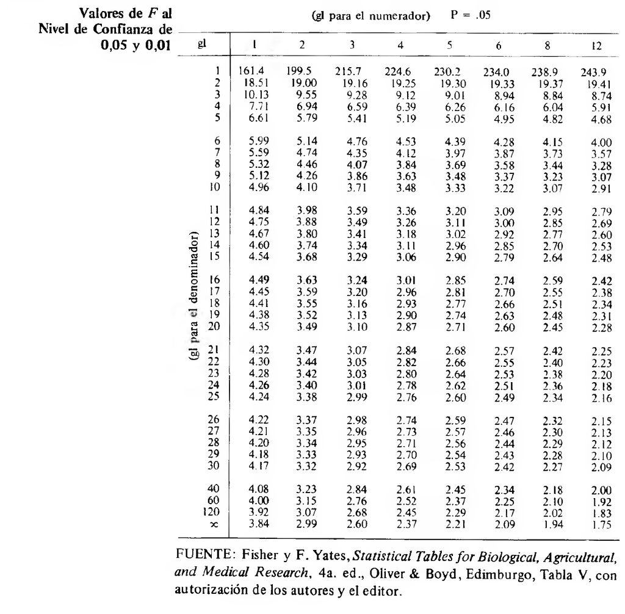

Fuente: Levin, 1999.

#### Paso #1:

Encontrar la media para cada muestra

$$\begin{equation*}
\bar{X}_{1}=\frac{\sum X_{1}}{N} ~~~~~~~ \bar{X}_{2}=\frac{\sum
X_{2}}{N} ~~~~~~~ \bar{X}_{3}=\frac{\sum X_{3}}{N}
\end{equation*}$$

#### Paso #2:

Encontrar la suma total de los cuadrados

$$\begin{equation*}
SC_{total}=\sum X{}_{total}^{2}-\frac{(\sum X_{total})^{2}}{N_{total}}
\end{equation*}$$

#### Paso #3:

Encontrar la suma de los cuadrados entre los grupos

$$\begin{equation*}
SC_{entre}=\left[\sum\frac{(\sum X)^{2}}{N}\right]-\frac{(\sum
X_{total})^{2}}{N_{total}}
\end{equation*}$$

#### Paso #4:

Encontrar la suma de los cuadrados dentro de los grupos (dos ecuaciones posibles)

$$\begin{equation*}
SC_{dentro}=\sum\left[(\sum X^{2})-\frac{(\sum X)^{2}}{N}\right]
\end{equation*}$$

$$\begin{equation*}
también~ se~ puede~ obtener~ con~ la~ siguiente~ ecuación:
\end{equation*}$$

$$\begin{equation*}
SC_{dentro}=SC_{total}-SC_{entre}
\end{equation*}$$

#### Paso #5:

Encontrar los grados de libertad entre los grupos

$$\begin{equation*}
gl_{entre}=k-1
\end{equation*}$$

k = la cantidad de grupos

#### Paso #6:

Encontrar los grados de libertad dentro los grupos

$$\begin{equation*}
gl_{dentro}=N_{total}-k
\end{equation*}$$

#### Paso #7:

Encontrar la media cuadrática entre grupos

$$\begin{equation*}
\mu C_{entre}=\frac{SC_{entre}}{gl_{entre}}
\end{equation*}$$

#### Paso #8:

Encontrar la media cuadrática dentro de los grupos

$$\begin{equation*}
\mu C_{dentro}=\frac{SC_{dentro}}{gl_{dentro}}
\end{equation*}$$

#### Paso #9:

Obtener la razón F

$$\begin{equation*}
F=\frac{\mu C_{entre}}{\mu C_{dentro}}
\end{equation*}$$

#### Paso #10:

Comparar la razón F experimental con la razón F teórica en la tabla

$$\begin{equation*}
P=0,05/0,01
\end{equation*}$$

$$\begin{equation*}
gl=\frac{gl_{entre}}{gl_{dentro}}
\end{equation*}$$

$$\begin{equation*}
F-experimental=...
\end{equation*}$$

$$\begin{equation*}
F-teorica=...
\end{equation*}$$

#### Paso #11:

Determinar las diferencias entre medias

Cuando se rechaza la hipótesis nula y se acepta la hipótesis alternativa, es necesario determinar si las diferencias significativas aplican para todos los grupos o solo para la relación entre algunos de ellos. Por consiguiente hay que obtener la diferencia de medias entre todas las combinaciones posibles entre grupos.

Por ejemplo, si hay tres grupos; A, B y C. Es necesario obtener la diferencia de medias entre:

- Grupo A y Grupo B
- Grupo A y Grupo C
- Grupo B y Grupo C

#### Paso #12:

Determinar el q-alpha con la tabla I del libro Levin (1999)

Se requiere determinar el q-alpha de acuerdo con la tabla del porcentaje student. Para ello es necesario previamente identificar las siguientes variables:

- grados de libertad para la media cuadrática dentro de los grupos
- cantidad de grupos
- nivel de confianza alpha ($\alpha$)

Con ello es posible buscar el valor en la siguiente tabla.

**Tabla 4. Valores q-alpha: Puntos de porcentaje del rango student**

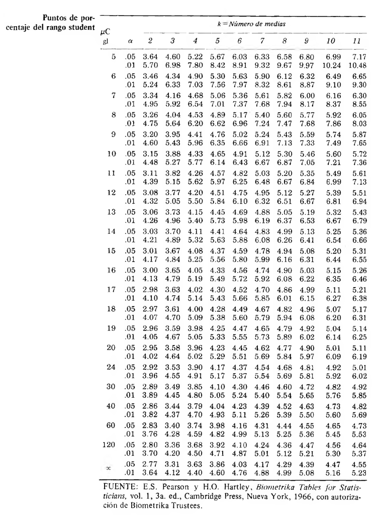

Fuente: Levin, 1999.

#### Paso #13:

Cálculo de la DSH de Tukey (Diferencia Significativa Honesta)

$$\begin{equation*}
DSH=q\alpha\sqrt{\frac{\mu C_{dentro}}{n}}
\end{equation*}$$

donde:

$DSH$ = Diferencia Significativa Honesta

$q\alpha$ = un valor de la tabla a un nivel de confianza ($\alpha$) dado para el número máximo de medias que se estén comparando

$\mu C_{dentro}$ = la media cuadrática dentro de los grupos (que se obtuvo del análisis de varianza)

$n$ = el número de entrevistados en cada grupo (supone el mismo número en cada grupo)

#### Paso #14:

Comparar el valor de DSH con cada una de las diferencias de medias e interpretar

Cuando la diferencia de medias entre los grupos es mayor al valor obtenido de DSH, significa que sí hay diferencia significativa entre esos dos grupos.

### Procedimiento y código

Ejemplo con un set de datos.

**Tabla 5. Ejemplo análisis de varianza**

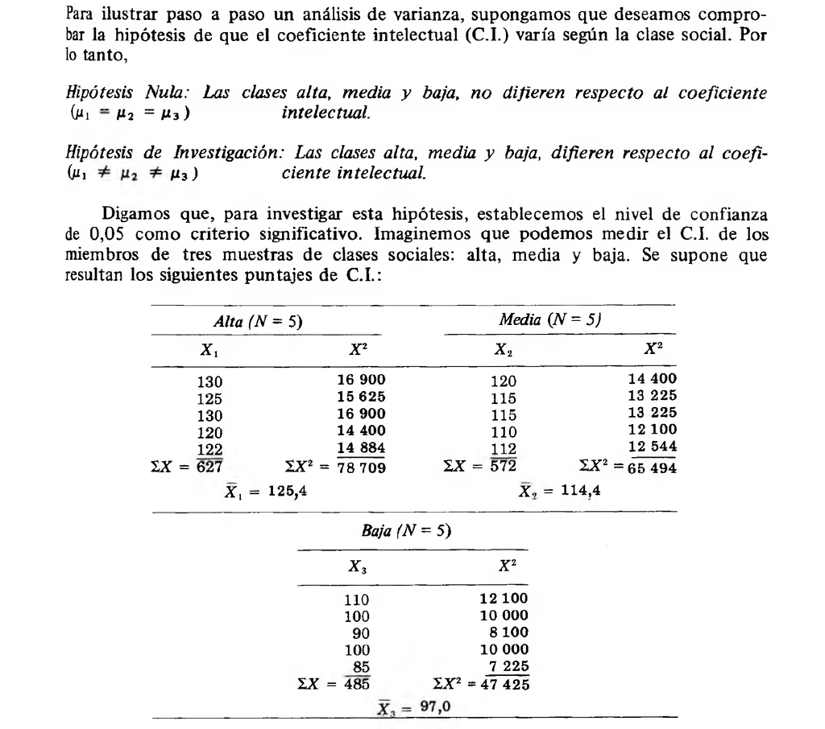

Fuente: Levin, 1999.

Supongamos que deseamos comprobar la hipótesis de que el coeficiente intelectual (C.I.) varía según la clase social. Entonces se plantean las hipótesis del análisis.

**Hipótesis nula (H0):** Las clases alta, media y baja, no difieren respecto al coeficiente intelectual.

**Hipótesis alternativa (H1):** Las clases alta, media y baja, difieren respecto al coeficiente intelectual.

Con ello se puede proceder al análisis.

```r
# se cargan los datos de un CSV

setwd("~/Library/CloudStorage/GoogleDrive-steffangc@gmail.com/My Drive/Docencia-Uni/UCR/APCuantitativo/2025-II/RMarkdown")
datos <- read.csv("Anova_ejemplo.csv", sep = ";")
datos
```

```
##   Alta Media Baja
## 1  130   120  110
## 2  125   115  100
## 3  130   115   90
## 4  120   110  100
## 5  122   112   85
```

**PASO #1:** Encontrar la media para cada muestra

$$\begin{equation*}
\bar{X}_{1}=\frac{\sum X_{1}}{N} ~~~~~~~ \bar{X}_{2}=\frac{\sum
X_{2}}{N} ~~~~~~~ \bar{X}_{3}=\frac{\sum X_{3}}{N}
\end{equation*}$$

```r
# Promedios

prom_alta = mean(datos$Alta)
prom_alta
```

```
## [1] 125.4
```

```r
prom_media = mean(datos$Media)
prom_media
```

```
## [1] 114.4
```

```r
prom_baja = mean(datos$Baja)
prom_baja
```

```
## [1] 97
```

**PASO #2:** Encontrar la suma total de los cuadrados

$$\begin{equation*}
SC_{total}=\sum X{}_{total}^{2}-\frac{(\sum X_{total})^{2}}{N_{total}}
\end{equation*}$$

```r
# Se calcula el N-total (ojo con el dataframe original)
N_total <- nrow(datos) * ncol(datos)
N_total
```

```
## [1] 15
```

```r
# Se calculan los valores al cuadrado sobre el datafram
datos$AltaCuad <- datos$Alta^2
datos$MediaCuad <- datos$Media^2
datos$BajaCuad <- datos$Baja^2
datos
```

```
##   Alta Media Baja AltaCuad MediaCuad BajaCuad
## 1  130   120  110    16900     14400    12100
## 2  125   115  100    15625     13225    10000
## 3  130   115   90    16900     13225     8100
## 4  120   110  100    14400     12100    10000
## 5  122   112   85    14884     12544     7225
```

```r
# Se calcula la fórmula
SC_total <- (sum(datos$AltaCuad) + sum(datos$MediaCuad) + sum(datos$BajaCuad)) -
  (sum(datos$Alta) + sum(datos$Media) + sum(datos$Baja))^2 / N_total

SC_total
```

```
## [1] 2570.933
```

**PASO #3:** Encontrar la suma de los cuadrados entre los grupos

$$\begin{equation*}
SC_{entre}=\left[\sum\frac{(\sum X)^{2}}{N}\right]-\frac{(\sum
X_{total})^{2}}{N_{total}}
\end{equation*}$$

```r
# se calcula el N
N <- nrow(datos)
N
```

```
## [1] 5
```

```r
# se calcula la fórmula
SC_entre <- (sum(datos$Alta)^2/N + sum(datos$Media)^2/N + sum(datos$Baja)^2/N) -
  ((sum(datos$Alta) + sum(datos$Media) + sum(datos$Baja))^2 / N_total)

SC_entre
```

```
## [1] 2050.533
```

**PASO #4:** Encontrar la suma de los cuadrados dentro de los grupos (dos ecuaciones posibles)

$$\begin{equation*}
SC_{dentro}=\sum\left[(\sum X^{2})-\frac{(\sum X)^{2}}{N}\right]
\end{equation*}$$

$$\begin{equation*}
también~ se~ puede~ obtener~ con~ la~ siguiente~ ecuación:
\end{equation*}$$

$$\begin{equation*}
SC_{dentro}=SC_{total}-SC_{entre}
\end{equation*}$$

```r
# se obtiene con la ecuacion despejada

SC_dentro <- SC_total - SC_entre
SC_dentro
```

```
## [1] 520.4
```

**PASO #5:** Encontrar los grados de libertad entre los grupos

$$\begin{equation*}
gl_{entre}=k-1
\end{equation*}$$

k = la cantidad de grupos

```r
# Se hace la ecuacion

k = 3 # tres grupos

gl_entre <- k - 1
gl_entre
```

```
## [1] 2
```

**PASO #6:** Encontrar los grados de libertad dentro los grupos

$$\begin{equation*}
gl_{dentro}=N_{total}-k
\end{equation*}$$

```r
# Se hace la ecuacion
gl_dentro <- N_total - k
gl_dentro
```

```
## [1] 12
```

**PASO #7:** Encontrar la media cuadrática entre grupos

$$\begin{equation*}
\mu C_{entre}=\frac{SC_{entre}}{gl_{entre}}
\end{equation*}$$

```r
# Se hace la ecuacion
miuCuad_entre <- SC_entre / gl_entre
miuCuad_entre
```

```
## [1] 1025.267
```

**PASO #8:** Encontrar la media cuadrática dentro de los grupos

$$\begin{equation*}
\mu C_{dentro}=\frac{SC_{dentro}}{gl_{dentro}}
\end{equation*}$$

```r
# Se hace la ecuacion
miuCuad_dentro <- SC_dentro / gl_dentro
miuCuad_dentro
```

```
## [1] 43.36667
```

**PASO #9:** Obtener la razón F

$$\begin{equation*}
F=\frac{\mu C_{entre}}{\mu C_{dentro}}
\end{equation*}$$

```r
# Se hace la ecuacion
razonF_exp <- miuCuad_entre / miuCuad_dentro
razonF_exp
```

```
## [1] 23.64181
```

**PASO #10:** Comparar la razón F experimental con la razón F teórica en la tabla

$$\begin{equation*}
P=0,05
\end{equation*}$$

$$\begin{equation*}
gl=\frac{2}{12}
\end{equation*}$$

$$\begin{equation*}
F-experimental= 23,64
\end{equation*}$$

$$\begin{equation*}
F-teorica= 3,88
\end{equation*}$$

#### Análisis de los resultados

Dado que la F-experimental es mayor que la F-teórica de la tabla, se rechaza la hipótesis nula (H0) y se acepta la hipótesis alternativa (H1). Es decir, sí existen diferencias en el Coeficiente Intelectual (CI) según clases sociales, de acuerdo con el experimento realizado.

Ahora es necesario determinar entre cuáles grupos ocurren diferencias significativas.

**PASO #11:** Determinar las diferencias entre medias

Para ello se utilizan los promedios de cada grupo y se obtienen las diferencias de medias entre las distintas combinaciones.

```r
# Diferencias entre medias

# alta y media
Dif_AltaMedia <- abs(prom_alta - prom_media)
Dif_AltaMedia
```

```
## [1] 11
```

```r
# alta y baja
Dif_AltaBaja <- abs(prom_alta - prom_baja)
Dif_AltaBaja
```

```
## [1] 28.4
```

```r
# media y baja
Dif_MediaBaja <- abs(prom_media - prom_baja)
Dif_MediaBaja
```

```
## [1] 17.4
```

**PASO #12:** Determinar el q-alpha con la tabla I del libro Levin (1999)

- grados de libertad para $\mu C_{dentro}$ = 12
- Valor k = 3
- Nivel de confianza $\alpha$ = P(0,05)
- Valor q-alpha en la tabla = 3,77

**PASO #13:** Cálculo de la DSH de Tukey (Diferencia Significativa Honesta)

$$\begin{equation*}
DSH=q\alpha\sqrt{\frac{\mu C_{dentro}}{n}}
\end{equation*}$$

```r
# Ecuacion DSH
DSH <- 3.77*sqrt(miuCuad_dentro / N)
DSH
```

```
## [1] 11.10285
```

**PASO #14:** Comparar el valor de DSH con cada una de las diferencias de medias e interpretar

- Diferencia entre Alta y Media (11) es menor que DSH (11,10). Entonces, no hay diferencias significativas entre estos dos grupos.
- Diferencia entre Alta y Baja (28,4) es mayor que DSH (11,10). Entonces, sí hay diferencias significativas entre estos dos grupos.
- Diferencia entre Media y Baja (17,4) es mayor que DSH (11,10). Entonces, sí hay diferencias significativas entre estos dos grupos.

#### Interpretación final del análisis ANOVA

El análisis confirma que sí hay diferencia significativas en los coeficientes intelectuales según clases sociales. Pero esas diferencias ocurren entre la clase Alta y Baja y entre la clase Media y Baja. No hay diferencias significativas entre la clase Alta y la Media.

### Comprobación ANOVA con función de R

Primero se cargan de nuevo los datos del ejemplo.

```r
# se vuelven a cargar los datos originales

setwd("~/Library/CloudStorage/GoogleDrive-steffangc@gmail.com/My Drive/Docencia-Uni/UCR/APCuantitativo/2025-II/RMarkdown")
datos <- read.csv("Anova_ejemplo.csv", sep = ";")
datos
```

```
##   Alta Media Baja
## 1  130   120  110
## 2  125   115  100
## 3  130   115   90
## 4  120   110  100
## 5  122   112   85
```

Para correr la ANOVA con las funciones de R es necesario transformar la estructura del dataframe. La nueva estructura se llama `dataframe tidy`, porque agrupa las categorías “Alta / Media / Baja” en una sola columna. Para eso se utiliza la función `pivot_longer()` del paquete `tidyr`. La sintaxis del ejemplo es:

- `df_tidy <- datos %>% pivot_longer(1:3, names_to="clase", values_to = "ci")`.

Esa sintaxis significa:

- nuevo objeto “df_tidy”.
- Se usa el df “datos” %>%
- Se aplica la función pivot_longer( ).
  - El primer parámetro es indicar las columnas a las cuáles se les aplica la función. En este caso se aplica a las columnas de la 1 a la 3 (1:3).
  - names_to = se indica cómo se van a llamar los textos de las columnas. Acá los denominamos “clase”.
  - values_to = se indica cómo se van a llamar los valores del df. Acá los denominamos “ci”.

El resultado es un nuevo dataframe (df) con nueva “forma”. Pasa de tener 5 observaciones con 3 variables, a tener 15 observaciones y 2 variables. Compare ambos df y verá la transformación. Esto se conoce como un “reshape” del dataframes (df).

El procedimiento es el siguiente (requiere las bibliotecas `dplyr` y `tidyr`):

```r
library(tidyr)
library(dplyr)

# Se hace un pivot_longer para transformar el DF
df_tidy <- datos %>% pivot_longer(1:3, names_to="clase", values_to = "ci")
df_tidy
```

```
## # A tibble: 15 × 2
##    clase    ci
##    <chr> <int>
##  1 Alta    130
##  2 Media   120
##  3 Baja    110
##  4 Alta    125
##  5 Media   115
##  6 Baja    100
##  7 Alta    130
##  8 Media   115
##  9 Baja     90
## 10 Alta    120
## 11 Media   110
## 12 Baja    100
## 13 Alta    122
## 14 Media   112
## 15 Baja     85
```

```r
# Se revisan las categorías de la variable clase
unique(df_tidy$clase)
```

```
## [1] "Alta"  "Media" "Baja"
```

```r
# se convierte a factor la clase social
df_tidy$clase <- factor(df_tidy$clase, levels = c("Alta", "Media", "Baja"))

# se imprimen los niveles para chequear
levels(df_tidy$clase)
```

```
## [1] "Alta"  "Media" "Baja"
```

#### Función de R

En este caso la función de ANOVA se indica con `aov()` y sigue la estructura de: **coeficiente intelectual (ci) en función de la clase social (clase)**. Nótese que el símbolo `~` conocido como virgulilla (option + ñ en el teclado) establece la relación en la fórmula de la ANOVA

La interpretación de los resultados permite ver el `F-value` y el `p-value` denotado como `Pr(>F)`. Si se cumple que `p-value < 0.05` entonces se rechaza la hipótesis nula y se acepta la alternativa a un nivel de confianza del 95%. Es decir sí hay diferencias entre las medias.

En este caso el resultado indica un `p-value = 6.88e-05***`. Eso es lo mismo que **0,0000688**, claramente menor que 0,05. Además se denota con tres asteriscos que marcan el nivel de significancia de la prueba. En este caso una confianza muy cercana al 100%.

```r
# Función ANOVCA aov()
res_anova <- aov(ci ~ clase, data = df_tidy)

# se imprimen los resultados del modelo
summary(res_anova)
```

```
##             Df Sum Sq Mean Sq F value   Pr(>F)
## clase        2 2050.5  1025.3   23.64 6.88e-05 ***
## Residuals   12  520.4    43.4
## ---
## Signif. codes:  0 '***' 0.001 '**' 0.01 '*' 0.05 '.' 0.1 ' ' 1
```

De seguido se computa el DSH de Tukey para establecer en cuáles grupos la diferencia de medias es significativa. Para eso se utiliza la función `TukeyHSD()` y se le pasa como parámetro el resultado del ANOVA ya calculado.

Los resultados muestran las diferencias **(diff)** entre las medias de los tres grupos en este ejemplo (Alta, Media y Baja). ¿Cómo saber si esas diferencias son significativas? Se revisa el **p-value ajustado** que en los resultados aparece como **p adj**. Se utiliza la misma regla: si el **p-value** es menor que 0.05, entonces sí es significativo.

En este ejemplo se puede ver que las diferencias entre “Baja-Alta” y “Baja-Media” son las únicas dos que tienen un **p adj** < 0,05. Nótese que la diferencia entre “Media-Alta” está levemente por encima del nivel de significancia, pues el **p adj** en ese grupo es 0,0524062. Los resultados coinciden con el procedimiento manual y se llega a las mismas interpretaciones y conclusiones planteadas anteriormente.

```r
# se calcula el DSH de Tukey
TukeyHSD(res_anova)
```

```
##   Tukey multiple comparisons of means
##     95% family-wise confidence level
##
## Fit: aov(formula = ci ~ clase, data = df_tidy)
##
## $clase
##             diff       lwr         upr     p adj
## Media-Alta -11.0 -22.11147   0.1114733 0.0524062
## Baja-Alta  -28.4 -39.51147 -17.2885267 0.0000510
## Baja-Media -17.4 -28.51147  -6.2885267 0.0033905
```

# Pruebas no paramétricas

Las pruebas no paramétricas se utilizan cuando los supuestos de normalidad y de medición por intervalos no se pueden cumplir (requisitos para una prueba paramétrica como la razón z, la razón t o la razón F). Por consiguiente las pruebas no paramétricas son menos estrictas y menos poderosas que las pruebas paramétricas. Pero constituyen una herramienta de análisis válida para ciertos datos. En especial los que están medidos en escalas ordinales (rankings o similar) y/o agrupados por frecuencias según sea el caso.

## Chi cuadrado

De acuerdo con Levin (1999), el chi cuadrado es una prueba empleada para hacer comparaciones entre frecuencias más que entre puntajes medios. Esta prueba tiene que ver, fundamentalmente, con la diferencia entre las frecuencias obtenidas y las frecuencias esperadas. La frecuencia esperada se obtiene asumiendo que la frecuencia de cada grupo es la misma. Entonces, hay diferencias significativas entre los grupos sólo si las diferencias entre la frecuencias obtenidas y las frecuencias esperadas son lo suficientemente grandes. En ese caso se rechaza la hipótesis nula y se toma como válida la hipótesis alternativa.

La ecuación para el cálculo es:

$$\begin{equation*}
X^{2}=\sum\frac{(f_{o}-f_{e})^{2}}{f_{e}}
\end{equation*}$$

donde:

$X^{2}$ = Chi cuadrado  
$f_{o}$ = la frecuencia obtenida en la respectiva casilla  
$f_{e}$ = la frecuencia esperada en la respectiva casilla

Un ejemplo para ilustrar la forma de ordenar los datos. Supóngase que se extraen muestras aleatorias de 20 liberales y 20 conservadores, quienes podrían categorizarse como no rígidos o como rígidos respecto a los métodos de crianza de los niños.

Para este ejemplo se plantean las hipótesis:

**Hipótesis nula (H0):** La frecuencia relativa de los liberales y los conservadores de acuerdo con su rigidez para criar a los niños es la misma.

**Hipótesis alternativa (H1):** La frecuencia relativa de los liberales y los conservadores de acuerdo con su rigidez para criar a los niños varía significativamente.

La Tabla 6 muestra las frecuencias obtenidas que podrían resultar (Levin, 1999).

**Tabla 6. Ejemplo de tabla para chi cuadrado de 2x2**

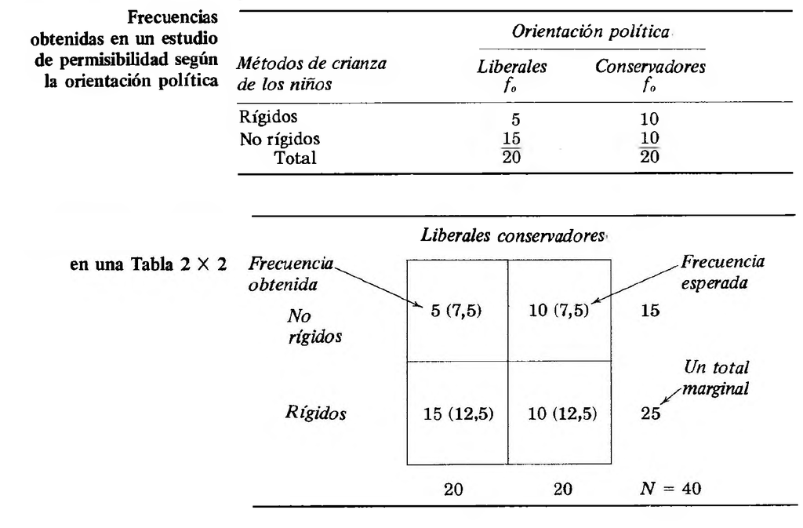

Fuente: Levin, 1999.

La frecuencia esperada se calcula de la siguiente forma:

$$\begin{equation*}
f_{e}=\frac{TM_{fila}*TM_{columna}}{N}
\end{equation*}$$

donde:

$f_{e}$ = frecuencia esperada

$TM_{fila}$ = Total marginal de la fila respectiva

$TM_{columna}$ = Total marginal de la columna respectiva

Los totales marginales en una matriz de 2x2 se pueden denotar de acuerdo con las casillas indicadas en la tabla 7.

**Tabla 7. Identificación de casillas en una tabla de 2x2**

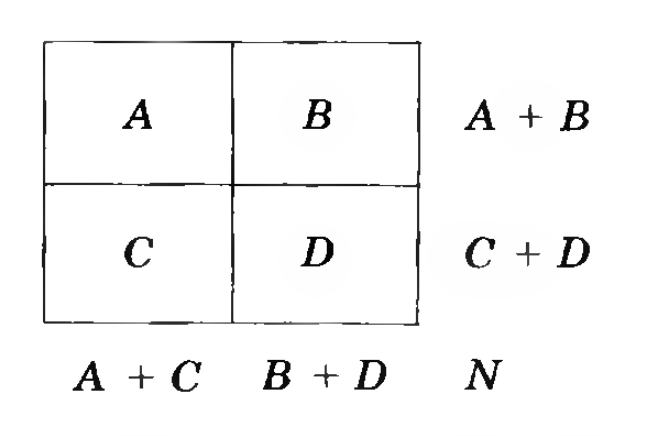

Fuente: Levin, 1999.

Para los datos de la tabla 6, las frecuencias esperadas se obtienen de la siguiente forma, utilizando la identificación de casillas de la tabla 7.

```r
# Se hace la matriz de datos
datos <- matrix(data = c(5, 15, 10, 10), nrow = 2)
datos
```

```
##      [,1] [,2]
## [1,]    5   10
## [2,]   15   10
```

```r
# Se obtiene el N total
n <-  sum(datos)
n
```

```
## [1] 40
```

```r
# se obtienen los valores de cada celda en la matriz
fo_A <- datos[1,1]
fo_A
```

```
## [1] 5
```

```r
fo_B <- datos[1,2]
fo_B
```

```
## [1] 10
```

```r
fo_C <- datos[2,1]
fo_C
```

```
## [1] 15
```

```r
fo_D <- datos[2,2]
fo_D
```

```
## [1] 10
```

```r
# se obtienen los totales marginales
tm_r1 <- datos[1,1] + datos[1,2]
tm_r1
```

```
## [1] 15
```

```r
tm_r2 <- datos[2,1] + datos[2,2]
tm_r2
```

```
## [1] 25
```

```r
tm_c1 <- datos[1,1] + datos[2,1]
tm_c1
```

```
## [1] 20
```

```r
tm_c2 <- datos[1,2] + datos[2,2]
tm_c2
```

```
## [1] 20
```

```r
# frecuencia esperada de casilla A
fe_A <- tm_r1 * tm_c1 / n
fe_A
```

```
## [1] 7.5
```

```r
# frecuencia esperada de casilla B
fe_B <- tm_r1 * tm_c2 / n
fe_B
```

```
## [1] 7.5
```

```r
# frecuencia esperada de casilla C
fe_C <- tm_r2 * tm_c1 / n
fe_C
```

```
## [1] 12.5
```

```r
# frecuencia esperada de casilla D
fe_D <- tm_r2 * tm_c2 / n
fe_D
```

```
## [1] 12.5
```

Hay una segunda forma de calcular el chi cuadrado para una tabla de 2x2, siguiendo la identificación de las casillas en la tabla 6. La ecuación es:

$$\begin{equation*}
X^{2}=\frac{N(AD-BC)^{2}}{(A+B)(C+D)(A+C)(B+D}
\end{equation*}$$

donde:

$A$ = frecuencia de la casilla A

$B$ = frecuencia de la casilla B

$C$ = frecuencia de la casilla C

$D$ = frecuencia de la casilla D

$N$ = el total de todas las casillas

Claras las dos formas y ecuaciones para el cálculo del Chi Cuadrado, se puede resolver el ejemplo con código de la siguiente forma, considerando que ya los datos están ordenados en la tabla (paso #1) y que se obtuvieron las frecuencias esperadas (paso #2)

#### Paso #3:

Restar las frecuencias esperadas a las frecuencias obtenidas

```r
# La resta de frecuencias para cada cuadrante se donda con "rf"

rf_A <- fo_A - fe_A
rf_A
```

```
## [1] -2.5
```

```r
rf_B <- fo_B - fe_B
rf_B
```

```
## [1] 2.5
```

```r
rf_C <- fo_C - fe_C
rf_C
```

```
## [1] 2.5
```

```r
rf_D <- fo_D - fe_D
rf_D
```

```
## [1] -2.5
```

#### Paso #4:

Elevar al cuadrado las diferencias

```r
# Las diferencias al cuadrado se denotan con "dCuad"

dCuad_A <- rf_A^2
dCuad_A
```

```
## [1] 6.25
```

```r
dCuad_B <- rf_B^2
dCuad_B
```

```
## [1] 6.25
```

```r
dCuad_C <- rf_C^2
dCuad_C
```

```
## [1] 6.25
```

```r
dCuad_D <- rf_D^2
dCuad_D
```

```
## [1] 6.25
```

#### Paso #5:

Dividir entre la frecuencia esperada

```r
# La division entre la frecuencia esperada se denota como "divFe"

divFe_A <- dCuad_A / fe_A
divFe_A
```

```
## [1] 0.8333333
```

```r
divFe_B <- dCuad_B / fe_B
divFe_B
```

```
## [1] 0.8333333
```

```r
divFe_C <- dCuad_C / fe_C
divFe_C
```

```
## [1] 0.5
```

```r
divFe_D <- dCuad_D / fe_D
divFe_D
```

```
## [1] 0.5
```

#### Paso #6:

Sumar los cocientes para obtener el Chi Cuadrado

```r
# Sumar los cocientes para obtener el Chi Cuadrado
ChiCuad <- divFe_A + divFe_B + divFe_C + divFe_D
ChiCuad
```

```
## [1] 2.666667
```

#### Paso #7:

Obtener los grados de libertad

$$\begin{equation*}
gl=(r-1)(c-1)
\end{equation*}$$

donde:

$gl$ = grados de libertad

$r$ = total de filas de la tabla de chi cuadrado

$c$ = total de columnas de la tabla de chi cuadrado

```r
gl <- (2-1)*(2-1)
gl
```

```
## [1] 1
```

#### Paso #8:

Buscar el valor de Chi Cuadrado teórico y comparar con el Chi Cuadrado experimental al grado de significancia elegido.

**Tabla 8. Tabla de valores Chi Cuadrado**

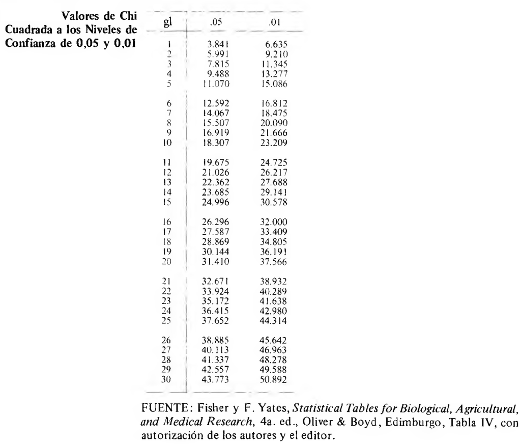

Fuente: Levin, 1999.

#### Resultados obtenidos

**Nivel de confianza** = 95%  
**gl** = 1  
**Chi cuadrado teórico** = 3,84  
**Chi cuadrado experimental** = 2,67

#### Análisis de los resultados

De acuerdo con el análisis realizado, el `chi-cuadrado experimental < chi-cuadrado teórico`. Entonces, se concluye que no existen diferencias significativas entre las frecuencias relativas de los liberales y los conservadores de acuerdo con la rigidez para criar a los niños. Por consiguiente, se acepta la hipótesis nula.

### Corrección de Yates

De acuerdo con Levin (1999), “si las frecuencias esperadas en un problema de chi cuadrada 2X2 son muy pequeñas (menos de 10 en una casilla), las fórmulas que hemos aprendido hasta aquí pueden producir un valor de chi cuadrada inflado. Nótese que esto es cierto sólo para las frecuencias esperadas y no para las frecuencias obtenidas realmente en el curso de la investigación, las cuales pueden ser de cualquier tamaño”.

La fórmula para la corrección de Yates es, toma el valor absoluto de la resta entre la frecuencia observada (fo) y la frecuencia esperada (fe). La ecuación completa es:

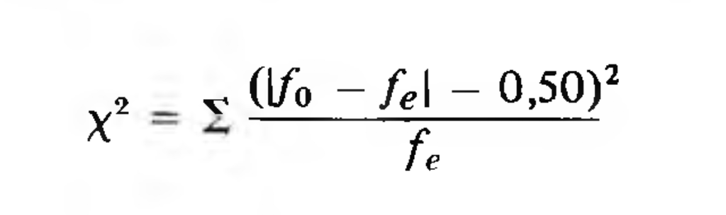

donde:

$fo$ = frecuencia observada

$fe$ = frecuencia esperada

Tómese el siguiente ejemplo del libro de Levin (1999).

```r
# Matriz de datos
datos <- matrix(data = c(5, 15, 10, 10), nrow = 2)
datos
```

```
##      [,1] [,2]
## [1,]    5   10
## [2,]   15   10
```

```r
# Se obtiene el N total
n <-  sum(datos)
n
```

```
## [1] 40
```

```r
# se obtienen los valores de cada celda en la matriz
fo_a <- datos[1,1]
fo_a
```

```
## [1] 5
```

```r
fo_b <- datos[1,2]
fo_b
```

```
## [1] 10
```

```r
fo_c <- datos[2,1]
fo_c
```

```
## [1] 15
```

```r
fo_d <- datos[2,2]
fo_d
```

```
## [1] 10
```

```r
# se obtienen los totales marginales
tm_r1 <- datos[1,1] + datos[1,2]
tm_r1
```

```
## [1] 15
```

```r
tm_r2 <- datos[2,1] + datos[2,2]
tm_r2
```

```
## [1] 25
```

```r
tm_c1 <- datos[1,1] + datos[2,1]
tm_c1
```

```
## [1] 20
```

```r
tm_c2 <- datos[1,2] + datos[2,2]
tm_c2
```

```
## [1] 20
```

```r
# Se obtienen las frecuencias esperadas
fe_a <- tm_r1 * tm_c1 / n
fe_a
```

```
## [1] 7.5
```

```r
fe_b <- tm_r1 * tm_c2 / n
fe_b
```

```
## [1] 7.5
```

```r
fe_c <- tm_r2 * tm_c1 / n
fe_c
```

```
## [1] 12.5
```

```r
fe_d <- tm_r2 * tm_c2 / n
fe_d
```

```
## [1] 12.5
```

```r
# Se resuelve la ecuación de la corrección de Yates para cada celda
yates_a <- ((abs(fo_a - fe_a) - 0.50) ^ 2) / fe_a
yates_a
```

```
## [1] 0.5333333
```

```r
yates_b <- ((abs(fo_b - fe_b) - 0.50) ^ 2) / fe_b
yates_b
```

```
## [1] 0.5333333
```

```r
yates_c <- ((abs(fo_c - fe_c) - 0.50) ^ 2) / fe_c
yates_c
```

```
## [1] 0.32
```

```r
yates_d <- ((abs(fo_d - fe_d) - 0.50) ^ 2) / fe_d
yates_d
```

```
## [1] 0.32
```

```r
# Se suman las correcciones de Yates de cada celda
yates <- yates_a + yates_b + yates_c + yates_d
yates
```

```
## [1] 1.706667
```

#### Resultados obtenidos con corrección de Yates

**Nivel de confianza** = 95%  
**gl** = 1  
**Chi cuadrado teórico** = 3,84  
**Chi cuadrado experimental** = 1.71

#### Análisis de los resultados

De acuerdo con el análisis realizado con la corrección de Yates, el `chi-cuadrado experimental < chi-cuadrado teórico`. Entonces se mantiene la conclusión de que no existen diferencias significativas entre las frecuencias relativas de los liberales y los conservadores de acuerdo con la rigidez para criar a los niños. Por consiguiente, se acepta la hipótesis nula.

### Comprobación con función de R

Al igual que en los casos anteriores, el paquete base de R tiene una función para calcular de forma automática el chi-cuadrado. La función se llama `chisq.test()`. Para calcularla es necesario crear una matriz con los datos ordenados de acuerdo como lo indica el libro. El parámetro para crear una matriz en R es `matrix()`. El siguiente ejemplo con código indica cada uno de los pasos para realizar el procedimiento.

```r
# Se crea la matriz de datos para el Chi-square
datos <- matrix(data = c(5, 15, 10, 10), ncol = 2)
datos
```

```
##      [,1] [,2]
## [1,]    5   10
## [2,]   15   10
```

```r
# Chi-cuadrado test. Definir parámetro correct = FALSE (sin corrección de Yates)
test <- chisq.test(datos, correct = FALSE)
test
```

```
##
##  Pearson's Chi-squared test
##
## data:  datos
## X-squared = 2.6667, df = 1, p-value = 0.1025
```

```r
# Se chequean las frecuencias esperadas
test$expected
```

```
##      [,1] [,2]
## [1,]  7.5  7.5
## [2,] 12.5 12.5
```

```r
# Lo correcto es aplicar la corrección de Yates de acuerdo con Levin(1999),
# para muestas de 2x2 con frecuencias esperadas menores a 10.
# Nótese que las frecuencias esperadas no cambian.

# Chi-cuadrado test. Definir parámetro correct = TRUE para la corrección de Yates
test2 <- chisq.test(datos, correct = TRUE)
test2
```

```
##
##  Pearson's Chi-squared test with Yates' continuity correction
##
## data:  datos
## X-squared = 1.7067, df = 1, p-value = 0.1914
```

```r
# Se chequean las frecuencias esperadas
test2$expected
```

```
##      [,1] [,2]
## [1,]  7.5  7.5
## [2,] 12.5 12.5
```

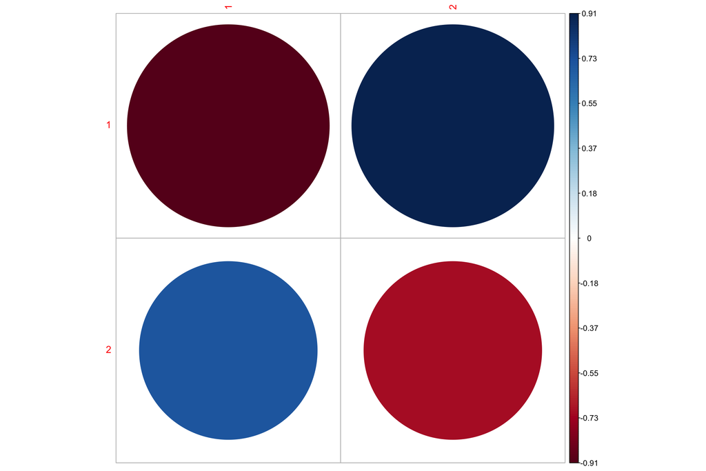

```r
# Gráfico para comparar los residuos del Chi-cuadrado
library(corrplot)
corrplot(test2$residuals, is.cor = FALSE)
```

### Respuesta:

En ambos casos los valores del chi-cuadrado coinciden con los calculados en los pasos anteriores.

# Correlación y regresión

En esta sección se estudian dos técnicas multivariadas de uso frecuente: la correlación y la regresión. Como indica Gómez (2016), “aunque no es fácil diferenciarlas de forma tajante, en la correlación puede decirse que las variables se estudian para descubrir si existe asociación entre ellas y, en caso de existir, medir su grado o intensidad. En la regresión, por otra parte, se estudia la naturaleza de la relación entre las variables y se trata de establecer una relación funcional que permite predecir una de ellas (variable dependiente), conociendo las otras (variables independientes)”.

El coeficiente de correlación lineal (coeficiente de Pearson) denotado con **r** puede asumir valores entre -1 y 1. El valor de este coeficiente indica la intensidad de la relación, y el signo mide la dirección de esa relación. Valores de 1 o -1 indican alta intensidad. Si **r = 1** se dice que las dos variables tienen una relación **directamente** proporcional, es decir, es una relación fuerte positiva. Cuando aumenta en una unidad la variable A, también aumenta en una unidad la variable B.

Por el contrario, si **r = -1** se dice que las dos variables tienen una relación **inversamente** proporcional, es decir, es una relación fuerte pero negativa. Cuando aumenta en una unidad la variable A, disminuye en una unidad la variable B.

Un valor de pearson igual a cero indica que las dos variables no tienen relación, en cuyo caso se dice que son variables independientes entre sí. El siguiente ejemplo muestra gráficos de distribución para diferentes valores del coeficiente de dispersión.

**Figura 5**

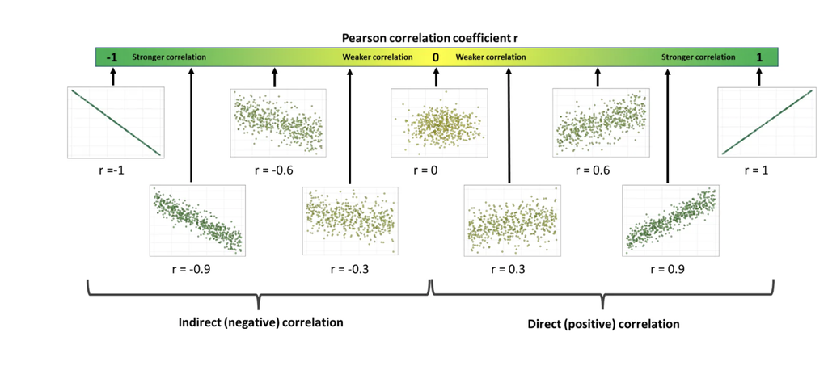

Fuente: Demeusy, 2023.

## Dataframes de ejemplo

Vamos a trabajar con algunos dataframes que están incluidos en R de forma nativa. El objetivo consiste en realizar las correlaciones a cada dataframee interpretar las relaciones.

Los dataframes son:

1. mtcars: contiene datos sobre marcas de autos en 1973-1974. Incluye 11 variables sobre cada auto, entre las cuáles están el número de cilindros, la potencia en caballos de fuerza, etc. El dataframes tiene 32 observaciones. El detalle completo de las variables se pueden ver en este enlace: https://erblast.github.io/easyalluvial/reference/mtcars2.html.
2. airquality: contiene registros de la calidad del aire en Nueva York en 1973. Tiene 6 variables (Ozone, Solar, Wind, Temp, etc.) y 154 observaciones. El detalle de las variables se pueden ver en: https://www.rdocumentation.org/packages/datasets/versions/3.6.2/topics/airquality.
3. USArrests: contiene datos sobre arrestos por varios crímenes en Estados Unidos durante 1973. Tiene cuatro variables (tipos de crímenes) y 50 observaciones, cada una referida a un Estado. El detalle se puede ver en: https://rdrr.io/r/datasets/USArrests.html.

```r
# Paquete
library(ggplot2)
library(corrplot)


# Se cargan y visualizan los dataframes
mtcars <- mtcars
head(mtcars)
```

```
##                    mpg cyl disp  hp drat    wt  qsec vs am gear carb
## Mazda RX4         21.0   6  160 110 3.90 2.620 16.46  0  1    4    4
## Mazda RX4 Wag     21.0   6  160 110 3.90 2.875 17.02  0  1    4    4
## Datsun 710        22.8   4  108  93 3.85 2.320 18.61  1  1    4    1
## Hornet 4 Drive    21.4   6  258 110 3.08 3.215 19.44  1  0    3    1
## Hornet Sportabout 18.7   8  360 175 3.15 3.440 17.02  0  0    3    2
## Valiant           18.1   6  225 105 2.76 3.460 20.22  1  0    3    1
```

```r
airquality <- airquality
head(airquality)
```

```
##   Ozone Solar.R Wind Temp Month Day
## 1    41     190  7.4   67     5   1
## 2    36     118  8.0   72     5   2
## 3    12     149 12.6   74     5   3
## 4    18     313 11.5   62     5   4
## 5    NA      NA 14.3   56     5   5
## 6    28      NA 14.9   66     5   6
```

```r
USArrests <- USArrests
head(USArrests)
```

```
##            Murder Assault UrbanPop Rape
## Alabama      13.2     236       58 21.2
## Alaska       10.0     263       48 44.5
## Arizona       8.1     294       80 31.0
## Arkansas      8.8     190       50 19.5
## California    9.0     276       91 40.6
## Colorado      7.9     204       78 38.7
```

### mtcars

Se realiza la correlación de todas las variables

```r
# Se calcula la matriz de correlaciones
cor_mtcars <- cor(mtcars)

# Se imprime toda la matriz porque es pequeña
print(cor_mtcars)
```

```
##             mpg        cyl       disp         hp        drat         wt
## mpg   1.0000000 -0.8521620 -0.8475514 -0.7761684  0.68117191 -0.8676594
## cyl  -0.8521620  1.0000000  0.9020329  0.8324475 -0.69993811  0.7824958
## disp -0.8475514  0.9020329  1.0000000  0.7909486 -0.71021393  0.8879799
## hp   -0.7761684  0.8324475  0.7909486  1.0000000 -0.44875912  0.6587479
## drat  0.6811719 -0.6999381 -0.7102139 -0.4487591  1.00000000 -0.7124406
## wt   -0.8676594  0.7824958  0.8879799  0.6587479 -0.71244065  1.0000000
## qsec  0.4186840 -0.5912421 -0.4336979 -0.7082234  0.09120476 -0.1747159
## vs    0.6640389 -0.8108118 -0.7104159 -0.7230967  0.44027846 -0.5549157
## am    0.5998324 -0.5226070 -0.5912270 -0.2432043  0.71271113 -0.6924953
## gear  0.4802848 -0.4926866 -0.5555692 -0.1257043  0.69961013 -0.5832870
## carb -0.5509251  0.5269883  0.3949769  0.7498125 -0.09078980  0.4276059
##             qsec         vs          am       gear        carb
## mpg   0.41868403  0.6640389  0.59983243  0.4802848 -0.55092507
## cyl  -0.59124207 -0.8108118 -0.52260705 -0.4926866  0.52698829
## disp -0.43369788 -0.7104159 -0.59122704 -0.5555692  0.39497686
## hp   -0.70822339 -0.7230967 -0.24320426 -0.1257043  0.74981247
## drat  0.09120476  0.4402785  0.71271113  0.6996101 -0.09078980
## wt   -0.17471588 -0.5549157 -0.69249526 -0.5832870  0.42760594
## qsec  1.00000000  0.7445354 -0.22986086 -0.2126822 -0.65624923
## vs    0.74453544  1.0000000  0.16834512  0.2060233 -0.56960714
## am   -0.22986086  0.1683451  1.00000000  0.7940588  0.05753435
## gear -0.21268223  0.2060233  0.79405876  1.0000000  0.27407284
## carb -0.65624923 -0.5696071  0.05753435  0.2740728  1.00000000
```

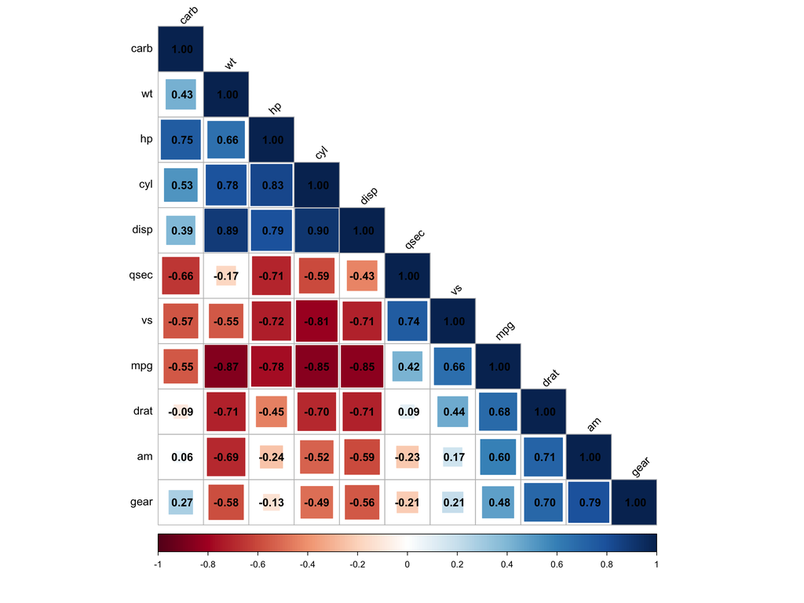

```r
# Se usan cuadrados para el gráfico: method="square".
corrplot(cor_mtcars, method="square",
         type="lower",
         order="hclust",
         tl.col="black",
         tl.srt=45,
         addCoef.col = TRUE)
```

Las correlaciones están indicadas con color y su valor dentro del gráfico del correlograma. ¿Cómo se ven los datos en casos concretos?.

- **Correlación entre mpg y wt = -0.87**

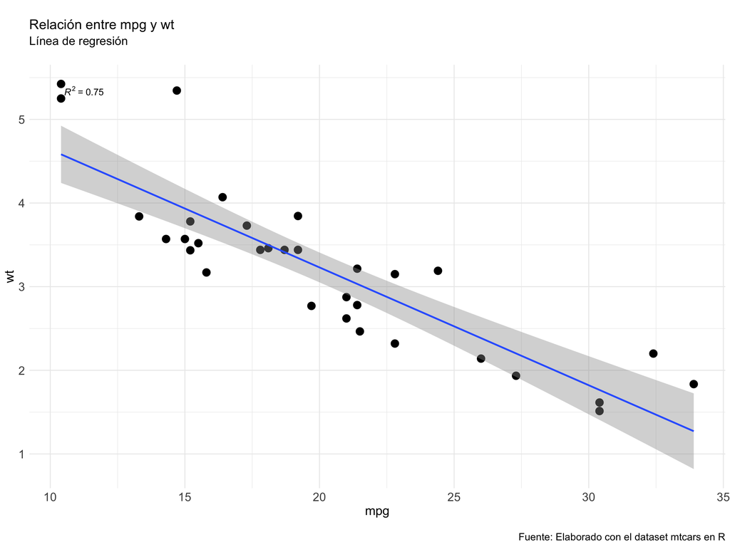

```r
# Para agregar el R2 se requiere el paquete "ggpmisc"
# es posible que también requieran instalar el paquete "ggpp"
library(ggpmisc)

# Gráfico
ggplot(mtcars, aes(x= mpg, y=wt)) +
  geom_point(size=4) +
  geom_smooth(method = "lm") +
  stat_poly_eq() + # del paquete ggpmisc (agrega el R2)
  theme_minimal() +
  theme(axis.title = element_text(size = 15), axis.text = element_text(size = 14)) +
  theme(plot.title = element_text(size = 16), plot.subtitle = element_text(size = 14), plot.caption = element_text(size = 12)) +
  labs(title="\nRelación entre mpg y wt",
       subtitle = "Línea de regresión\n",
       caption = "\nFuente: Elaborado con el dataset mtcars en R")
```

Como se puede apreciar, la correlación entre la eficiencia en el consumo de combustible, medido en millas recorridas por galón de combustible (mpg), aumenta conforme el peso (wt) del auto disminuye. Tiene sentido, autos más livianos logran recorrer más distancia por galón, que autos muy pesados. Por eso se dice que la relación es inversamente proporcional, o lo que es lo mismo, una relación negativa. En este caso el **r de Pearson = -0.87**.

Nótese dos cosas más: primero la pendiente en el gráfico de puntos y la línea azul. Dado que es una relación negativa, los puntos (y por consiguiente la línea azul de regresión) tienen una pendiente decreciente. Segundo, que el gráfico de dispersión (puntos), también tiene un indicador que se llama **R2**. Este es el coeficiente de determinación, relacionado con el análisis de regresión. La línea azul del gráfico es la línea de regresión. Algo que veremos con más detalle en las siguientes clases. El **R2** indica la robustez de la relación en un modelo de regresión.

## Ejercicios

Realice el gráfico y análisis para:

- Las dos variables con la correlación más alta positiva en mtcars.
- Las dos variables con la correlación más cercana a cero en mtcars.

### airquality

Se realiza la correlación de todas las variables. Cuando hay NA en el dataframe se sugiere eliminarlos para correr las correlaciones.

```r
airquality_tidy <- na.omit(airquality)

# Se calcula la matriz de correlaciones
cor_air <- cor(airquality_tidy)

# Se imprime toda la matriz porque es pequeña
print(cor_air)
```

```
##                Ozone     Solar.R        Wind       Temp        Month
## Ozone    1.000000000  0.34834169 -0.61249658  0.6985414  0.142885168
## Solar.R  0.348341693  1.00000000 -0.12718345  0.2940876 -0.074066683
## Wind    -0.612496576 -0.12718345  1.00000000 -0.4971897 -0.194495804
## Temp     0.698541410  0.29408764 -0.49718972  1.0000000  0.403971709
## Month    0.142885168 -0.07406668 -0.19449580  0.4039717  1.000000000
## Day     -0.005189769 -0.05775380  0.04987102 -0.0965458 -0.009001079
##                  Day
## Ozone   -0.005189769
## Solar.R -0.057753801
## Wind     0.049871017
## Temp    -0.096545800
## Month   -0.009001079
## Day      1.000000000
```

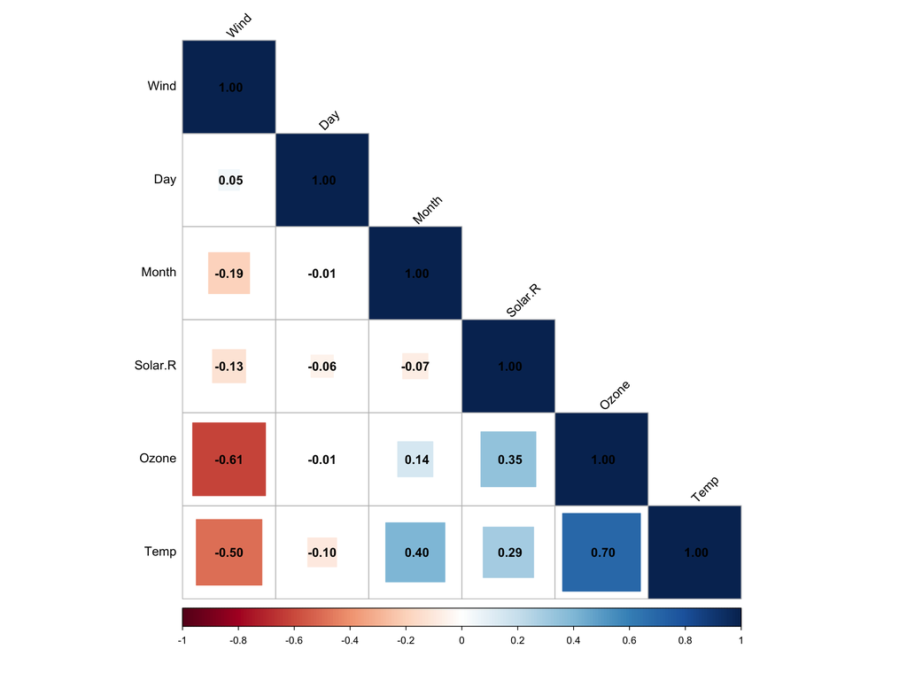

```r
# Se usan cuadrados para el gráfico: method="square".
corrplot(cor_air, method="square",
         type="lower",
         order="hclust",
         tl.col="black",
         tl.srt=45,
         addCoef.col = TRUE)
```

### USArrests

Se realiza la correlación de todas las variables.

```r
# Se calcula la matriz de correlaciones
cor_arrests <- cor(USArrests)

# Se imprime toda la matriz porque es pequeña
print(cor_arrests)
```

```
##              Murder   Assault   UrbanPop      Rape
## Murder   1.00000000 0.8018733 0.06957262 0.5635788
## Assault  0.80187331 1.0000000 0.25887170 0.6652412
## UrbanPop 0.06957262 0.2588717 1.00000000 0.4113412
## Rape     0.56357883 0.6652412 0.41134124 1.0000000
```

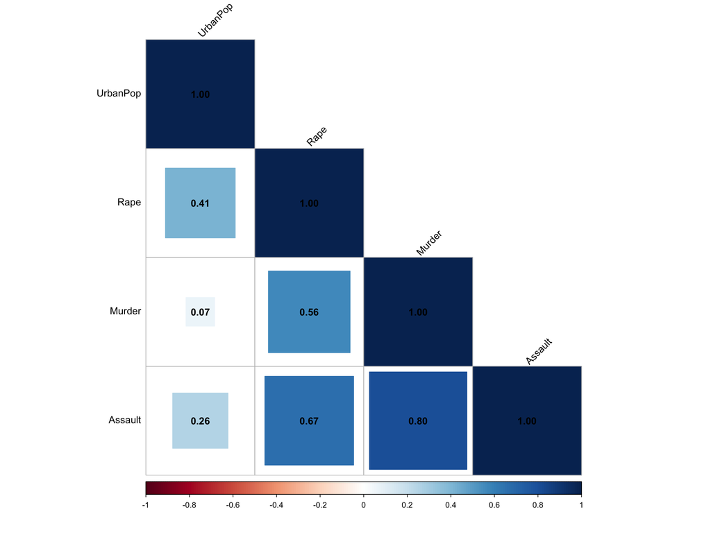

```r
# Se usan cuadrados para el gráfico: method="square".
corrplot(cor_arrests, method="square",
         type="lower",
         order="hclust",
         tl.col="black",
         tl.srt=45,
         addCoef.col = TRUE)
```

## Regresión: datos como en la naturaleza

El análisis de regresión es una técnica estadística que permite a los investigadores determinar la relación entre variables. En el análisis bivariado, evaluamos la relación entre un predictor y una variable de respuesta. Para dar un ejemplo, un análisis bivariado podría considerar cómo el ser hombre (predictor) afecta la probabilidad de votar por un Candidato A (respuesta).

Por supuesto, los análisis bivariados son raros porque las preguntas que desconciertan a la comunidad de ciencias sociales suelen ser bastante más complejas. En el ejemplo anterior, votar por el candidato A seguramente no se puede explicar por completo solo por el género. La regresión múltiple, donde tenemos una respuesta pero múltiples predictores, es mucho más común y constituye la base del análisis cuantitativo (Vargas, 2016).

En este caso usamos datos falsos que creamos para efectos de ilustar los conceptos. Al jugar el papel de la Naturaleza, asignamos valores ex-ante a la relación entre nuestras variables. Dado que somos “la Naturaleza”, sabemos completamente cuál es la verdadera relación entre nuestra variable. Es decir, sabemos de previo los valores que tienen las variables y el peso de sus interacciones. Esto es con fines didácticos, por supuesto, las cosas no son tan fáciles en la vida real…

El ejemplo de ejecución de hoy considerará el apoyo de un individuo al ejecutivo / alcalde local. La **variable de respuesta** es un termómetro de sensación que varía de 0 a 100, con temperaturas más cálidas que indican opiniones más favorables para el alcalde. Vamos a llamar a esta variable, `el termómetro`. Los **predictores** son:

- **age:** una variable aleatoria continua que se distribuye normalmente,
- **college:** una variable aleatoria dicotómica que toma el valor de 1 si la persona obtuvo un título universitario,
- **income:** una variable aleatoria continua que indica los ingresos de los individuos en miles de dólares estadounidenses.

Creamos cada una de estas variables:

```r
# Crear variables predictoras
# De las siguientes distribuciones sacamos 100 observaciones


# Debemos usar "set.seed" para fijar el mismo valor de inicio
# y que nuestro trabajo sea replicable
set.seed(333)



# Esto crea la variable *age* que se extrae de la distribución normal
# con media 45 y st. dev. 15. Se convierte a número entero con: as.integer()
age <- as.integer(rnorm(100,45,15))
head(age)
```

```
## [1] 43 74 14 49 22 40
```

```r
# Esto crea la variable * colegio * que se extrae de la distribución
# binomial, donde la probabilidad de obtener un valor = 1 es 0.3
college <- rbinom(100,1,0.3)
head(college)
```

```
## [1] 0 0 0 1 0 1
```

```r
# Esto crea la variable * ingreso * en miles de dólares que se extrae de la distribución beta con
# los parámetros de forma 2 y 8, de manera que tiene un ligero sesgo positivo.
income <- 10*rbeta(100,2,8)
head(income)
```

```
## [1] 2.4427731 3.1663986 3.2047044 1.1211726 0.2223342 2.2907541
```

El primer paso siempre es graficar estas variables para asegurarnos de que hemos creado las variables especificadas correctamente, pero tendrán que confiar que así es por el momento. Más adelante haremos histogramas y diagramas de densidad de las variables.

Ahora nos interesa pasar a crear la **variable dependiente** especificaremos un predictor lineal:

$thermometer_{i}=\alpha+age_{i}\ast\beta1+college_{i}\ast\beta2+income_{i}\ast\beta3+\epsilon_{i}$

Comprender lo que dice esta ecuación es fundamental para comprender el análisis de regresión. Recuerde, dado que jugamos el papel de la naturaleza, podemos especificar la relación exacta entre el termómetro y todas las demás variables.

La ecuación anterior dice que en nuestro universo los valores del termómetro para la persona **i** son una función lineal de un parámetro $\alpha$, para cada persona **i**, valores de `age`, `college`, `income` y un término de error $\epsilon$.

Nótese que cada predictor tiene un **beta** que pondera sus efectos, y se denota: $\beta_{j}$ con $j=1,2,3$. Estos parámetros **beta** son los que el análisis de regresión procura calcular de la mejor forma posible, y denotan el efecto de cualquier variable predictora, cuando todo lo demás se mantiene constante.

Para obtener nuestra variable dependiente, simplemente debemos especificar los valores de los parámetros y sumarlos.

```r
# Crear variable dependiente y coeficientes



#El intercepto ( intercept) es la sensación del termómetro hacia el alcalde cuando todas las
#variables se establecen en cero. En este caso sería el valor del termómetro cuando la persona
#tiene 0 años, no tiene educación universitaria ni ingresos. Esto no tiene sentido, lo que pone
#de relieve el hecho de que el intercepto no siempre es interpretable.
a <- 80
head(a)
```

```
## [1] 80
```

```r
# Beta 1 dice que un aumento de un año en la edad disminuyó el apoyo al alcalde en .5 puntos
b1 <- (-.5)
head(b1)
```

```
## [1] -0.5
```

```r
# Beta2 dice que tener una educación universitaria aumenta el apoyo al alcalde en 15 puntos.
b2 <- 15
head(b2)
```

```
## [1] 15
```

```r
# Beta3 dice que por cada aumento de mil dólares en ingresos,
# se reduce el apoyo al alcalde en 2 puntos.
b3 <- (-2)
head(b3)
```

```
## [1] -2
```

```r
#El término de error se extrae de la normal, media 0, st.dev 2.5
e <- rnorm(100,0,2.5)
head(e)
```

```
## [1]  2.7320347 -0.6951001  0.9527553 -1.2673094  0.2347320 -3.0075970
```

```r
#Entonces, nuestros valores para "y" son una función de "a", más cada uno
#de los predictores multiplicado por su beta (el peso de influencia), más un término de error.
y <- a + age*b1 + college*b2 + income*b3 + e
head(y)
```

```
## [1] 56.34649 35.97210 67.54335 66.99035 68.79006 67.41089
```

```r
# Renombramos la variable Y
thermometer <- y
head(thermometer)
```

```
## [1] 56.34649 35.97210 67.54335 66.99035 68.79006 67.41089
```

```r
 # se crea un conjunto de datos para usar posteriormente.
mayor <- as.data.frame(cbind(thermometer,
                          age,
                          college,
                          income))


head(mayor, 20)
```

```
##    thermometer age college    income
## 1     56.34649  43       0 2.4427731
## 2     35.97210  74       0 3.1663986
## 3     67.54335  14       0 3.2047044
## 4     66.99035  49       1 1.1211726
## 5     68.79006  22       0 0.2223342
## 6     67.41089  40       1 2.2907541
## 7     57.89252  63       1 1.9091441
## 8     46.19084  54       0 3.0704284
## 9     55.01948  50       0 1.3260681
## 10    58.45784  36       0 3.3354371
## 11    65.02673  28       0 0.9234177
## 12    62.64897  31       0 0.3132539
## 13    54.12041  45       0 0.6221541
## 14    57.30492  36       0 2.3343211
## 15    63.93153  32       0 0.9735026
## 16    56.34064  46       0 1.8329786
## 17    45.58275  50       0 4.8084730
## 18    56.30459  45       0 0.6252685
## 19    38.98010  65       0 3.3547159
## 20    52.57939  39       0 3.7738425
```

```r
tail(mayor, 20)
```

```
##     thermometer age college    income
## 81     57.47944  51       0 1.4699686
## 82     63.32681  58       1 2.2656832
## 83     80.26633  27       1 0.6140463
## 84     66.42080  23       0 2.7902956
## 85     58.30693  38       0 2.3068625
## 86     46.19962  48       0 4.4138639
## 87     70.96261  47       1 1.1564104
## 88     46.38837  52       0 2.4797723
## 89     65.84343  46       1 2.3492457
## 90     80.77338  24       1 1.7765727
## 91     57.81252  59       1 2.5035914
## 92     66.58275  49       1 2.7758816
## 93     63.99379  59       1 2.7221732
## 94     46.94066  67       0 0.7910539
## 95     55.85306  38       0 3.9331852
## 96     53.68124  44       0 1.4520175
## 97     51.94979  50       0 2.2744053
## 98     63.05945  17       0 2.2997242
## 99     54.46951  44       0 2.7763747
## 100    53.72554  50       0 0.5744756
```